# Supervised Learning : Survival Analysis and Descriptive Modelling for a Three-Group Right-Censored Data with Time-Independent Variables Using Cox Proportional Hazards Model

[John Pauline Pineda](https://github.com/JohnPaulinePineda)

May 6, 2022

# **1. Table of Contents**

## 1.1 Sample Data

The **Cancer** dataset from the book **Supervised Machine Learning** was used for this illustrated example.  
Preliminary dataset assessment:  
**[A]** 228 Rows (observations composed of advanced lung cancer patients)  
**[B]** 9 Columns (variables)  
**[B.1]** 1/9 Factor variable = ph.ecog (factor) referring to the ECOG performance score (0=best, 3=worst) which describes the level of functioning of patients in terms of their ability to care for themselves, daily activity, and physical ability.  
**[B.1.1]** Asymptomatic = ECOG performance score 0 (asymptomatic)  
**[B.1.2]** Ambulatory = ECOG performance score 1 (symptomatic but completely ambulatory)  
**[B.1.3]** Bedridden = ECOG performance score 2 (symptomatic but <50% in bed) or ECOG performance score 3 (symptomatic but >50% in bed)  
**[B.2]** 1/9 Censoring variable = status (factor)  
**[B.2.1]** 1 = event, patient died before the end of the study  
**[B.2.2]** 0 = censored or non-event, patient remains alive until the end of the study, lost to follow-up, experiences a different event that makes further follow-up impossible or withdraws before the end of the study  
**[B.3]** 1/9 Response variables = time (numeric)  
**[B.3.1]** time = time in days a patient stays alive up to the point of the patient’s death or being censored  
**[B.4]** 1/9 Covariate variable = age (numeric)  
**[B.4.1]** age = patient’s age in years during the conduct of the study  
**[B.5]** 1/9 Covariate variable = sex (factor)  
**[B.5.1]** sex = patient’s sex at birth  
**[B.6]** 1/9 Covariate variable = ph.karno (numeric)  
**[B.6.1]** ph.karno = Karnofsky performance score (bad=0,good=100) rated by physician  
**[B.7]** 1/9 Covariate variable = pat.karno: (numeric)  
**[B.7.1]** pat.karno = Karnofsky performance score (bad=0,good=100) rated by physician  
**[B.8]** 1/9 Covariate variable = meal.cal (numeric)  
**[B.8.1]** meal.cal = calories consumed at meals  
**[B.9]** 1/9 Covariate variable = wt.loss (numeric)  
**[B.9.1]** wt.loss = weight loss in last six months

**Code Chunk | Output**

```r
##################################
# Loading R libraries
##################################
library(moments)
library(car)
library(multcomp)
library(effects)
library(psych)
library(ggplot2)
library(dplyr)
library(ggpubr)
library(rstatix)
library(ggfortify)
library(trend)
library(survival)
library(rms)
library(survminer)
library(Hmisc)
library(finalfit)
library(knitr)
library(gtsummary)

##################################
# Loading the complete dataset
##################################
data(cancer)

##################################
# Reading and creating the complete dataset
##################################
DBP.Complete <- cancer

##################################
# Performing a general exploration of the dataset
##################################
dim(DBP.Complete)
```

```
## [1] 228  10
```

```r
str(DBP.Complete)
```

```
## 'data.frame':    228 obs. of  10 variables:
##  $ inst     : num  3 3 3 5 1 12 7 11 1 7 ...
##  $ time     : num  306 455 1010 210 883 ...
##  $ status   : num  2 2 1 2 2 1 2 2 2 2 ...
##  $ age      : num  74 68 56 57 60 74 68 71 53 61 ...
##  $ sex      : num  1 1 1 1 1 1 2 2 1 1 ...
##  $ ph.ecog  : num  1 0 0 1 0 1 2 2 1 2 ...
##  $ ph.karno : num  90 90 90 90 100 50 70 60 70 70 ...
##  $ pat.karno: num  100 90 90 60 90 80 60 80 80 70 ...
##  $ meal.cal : num  1175 1225 NA 1150 NA ...
##  $ wt.loss  : num  NA 15 15 11 0 0 10 1 16 34 ...
```

```r
summary(DBP.Complete)
```

```
##       inst            time            status           age
##  Min.   : 1.00   Min.   :   5.0   Min.   :1.000   Min.   :39.00
##  1st Qu.: 3.00   1st Qu.: 166.8   1st Qu.:1.000   1st Qu.:56.00
##  Median :11.00   Median : 255.5   Median :2.000   Median :63.00
##  Mean   :11.09   Mean   : 305.2   Mean   :1.724   Mean   :62.45
##  3rd Qu.:16.00   3rd Qu.: 396.5   3rd Qu.:2.000   3rd Qu.:69.00
##  Max.   :33.00   Max.   :1022.0   Max.   :2.000   Max.   :82.00
##  NA's   :1
##       sex           ph.ecog          ph.karno        pat.karno
##  Min.   :1.000   Min.   :0.0000   Min.   : 50.00   Min.   : 30.00
##  1st Qu.:1.000   1st Qu.:0.0000   1st Qu.: 75.00   1st Qu.: 70.00
##  Median :1.000   Median :1.0000   Median : 80.00   Median : 80.00
##  Mean   :1.395   Mean   :0.9515   Mean   : 81.94   Mean   : 79.96
##  3rd Qu.:2.000   3rd Qu.:1.0000   3rd Qu.: 90.00   3rd Qu.: 90.00
##  Max.   :2.000   Max.   :3.0000   Max.   :100.00   Max.   :100.00
##                  NA's   :1        NA's   :1        NA's   :3
##     meal.cal         wt.loss
##  Min.   :  96.0   Min.   :-24.000
##  1st Qu.: 635.0   1st Qu.:  0.000
##  Median : 975.0   Median :  7.000
##  Mean   : 928.8   Mean   :  9.832
##  3rd Qu.:1150.0   3rd Qu.: 15.750
##  Max.   :2600.0   Max.   : 68.000
##  NA's   :47       NA's   :14
```

```r
##################################
# Creating standard labels for certain variables
##################################
DBP.Complete$ph.ecog <- factor(DBP.Complete$ph.ecog,
                     levels = c(3, 2, 1, 0),
                     labels = c("Bedridden", "Bedridden", "Ambulatory","Asymptomatic"))

DBP.Complete$sex <- factor(DBP.Complete$sex,
                     levels = c(1, 2),
                     labels = c("Male", "Female"))

DBP.Complete$statuslevel <- factor(DBP.Complete$status,
                     levels = c(1, 2),
                     labels = c(0, 1))

DBP.Complete$status <- ifelse(DBP.Complete$status==2,1,0)

##################################
# Creating an analysis dataset without the subject information column
##################################
DBP.Analysis <- DBP.Complete[,-1]

##################################
# Creating a response-covariate dataset without the treatment column
##################################
DBP.Response.Covariate <- DBP.Analysis[,-5]

##################################
# Formulating a data type assessment summary
##################################
PDA <- DBP.Analysis
(PDA.Summary <- data.frame(
  Column.Index=c(1:length(names(PDA))),
  Column.Name= names(PDA),
  Column.Type=sapply(PDA, function(x) class(x)),
  row.names=NULL)
)
```

```
##    Column.Index Column.Name Column.Type
## 1             1        time     numeric
## 2             2      status     numeric
## 3             3         age     numeric
## 4             4         sex      factor
## 5             5     ph.ecog      factor
## 6             6    ph.karno     numeric
## 7             7   pat.karno     numeric
## 8             8    meal.cal     numeric
## 9             9     wt.loss     numeric
## 10           10 statuslevel      factor
```

## 1.2 Data Quality Assessment

**Code Chunk | Output**

```r
##################################
# Loading dataset
##################################
DQA <- DBP.Analysis

##################################
# Listing all predictors
##################################
DQA.Predictors <- DQA[,!names(DQA) %in% c("time","status")]

##################################
# Formulating an overall data quality assessment summary
##################################
(DQA.Summary <- data.frame(
  Column.Index=c(1:length(names(DQA))),
  Column.Name= names(DQA),
  Column.Type=sapply(DQA, function(x) class(x)),
  Row.Count=sapply(DQA, function(x) nrow(DQA)),
  NA.Count=sapply(DQA,function(x)sum(is.na(x))),
  Fill.Rate=sapply(DQA,function(x)format(round((sum(!is.na(x))/nrow(DQA)),3),nsmall=3)),
  row.names=NULL)
)
```

```
##    Column.Index Column.Name Column.Type Row.Count NA.Count Fill.Rate
## 1             1        time     numeric       228        0     1.000
## 2             2      status     numeric       228        0     1.000
## 3             3         age     numeric       228        0     1.000
## 4             4         sex      factor       228        0     1.000
## 5             5     ph.ecog      factor       228        1     0.996
## 6             6    ph.karno     numeric       228        1     0.996
## 7             7   pat.karno     numeric       228        3     0.987
## 8             8    meal.cal     numeric       228       47     0.794
## 9             9     wt.loss     numeric       228       14     0.939
## 10           10 statuslevel      factor       228        0     1.000
```

```r
##################################
# Listing all numeric predictors
##################################
DQA.Predictors.Numeric <- as.data.frame(DQA.Predictors[,sapply(DQA.Predictors, is.numeric)])

if (length(names(DQA.Predictors.Numeric))>0) {
    print(paste0("There are ",
               (length(names(DQA.Predictors.Numeric))),
               " numeric predictor variable(s)."))
} else {
  print("There are no numeric predictor variables.")
}
```

```
## [1] "There are 5 numeric predictor variable(s)."
```

```r
##################################
# Listing all factor predictors
##################################
DQA.Predictors.Factor <- as.data.frame(DQA.Predictors[,sapply(DQA.Predictors, is.factor)])

if (length(names(DQA.Predictors.Factor))>0) {
    print(paste0("There are ",
               (length(names(DQA.Predictors.Factor))),
               " factor predictor variable(s)."))
} else {
  print("There are no factor predictor variables.")
}
```

```
## [1] "There are 3 factor predictor variable(s)."
```

```r
##################################
# Checking for missing observations
##################################
if ((nrow(DQA.Summary[DQA.Summary$NA.Count>0,]))>0){
  print(paste0("Missing observations noted for ",
               (nrow(DQA.Summary[DQA.Summary$NA.Count>0,])),
               " variable(s) with NA.Count>0 and Fill.Rate<1.0."))
  DQA.Summary[DQA.Summary$NA.Count>0,]
} else {
  print("No missing observations noted.")
}
```

```
## [1] "Missing observations noted for 5 variable(s) with NA.Count>0 and Fill.Rate<1.0."
```

```
##   Column.Index Column.Name Column.Type Row.Count NA.Count Fill.Rate
## 5            5     ph.ecog      factor       228        1     0.996
## 6            6    ph.karno     numeric       228        1     0.996
## 7            7   pat.karno     numeric       228        3     0.987
## 8            8    meal.cal     numeric       228       47     0.794
## 9            9     wt.loss     numeric       228       14     0.939
```

```r
##################################
# Formulating a data quality assessment summary for numeric predictors
##################################

if (length(names(DQA.Predictors.Numeric))>0) {

  ##################################
  # Formulating a function to determine the first mode
  ##################################
  FirstModes <- function(x) {
    ux <- unique(na.omit(x))
    tab <- tabulate(match(x, ux))
    ux[tab == max(tab)]
  }

  ##################################
  # Formulating a function to determine the second mode
  ##################################
  SecondModes <- function(x) {
    ux <- unique(na.omit(x))
    tab <- tabulate(match(x, ux))
    fm = ux[tab == max(tab)]
    sm = na.omit(x)[!(na.omit(x) %in% fm)]
    usm <- unique(sm)
    tabsm <- tabulate(match(sm, usm))
    usm[tabsm == max(tabsm)]
  }

  (DQA.Predictors.Numeric.Summary <- data.frame(
  Column.Name= names(DQA.Predictors.Numeric),
  Column.Type=sapply(DQA.Predictors.Numeric, function(x) class(x)),
  Unique.Count=sapply(DQA.Predictors.Numeric, function(x) length(unique(x))),
  Unique.Count.Ratio=sapply(DQA.Predictors.Numeric, function(x) format(round((length(unique(x))/nrow(DQA.Predictors.Numeric)),3), nsmall=3)),
  First.Mode.Value=sapply(DQA.Predictors.Numeric, function(x) format(round((FirstModes(x)[1]),3),nsmall=3)),
  Second.Mode.Value=sapply(DQA.Predictors.Numeric, function(x) format(round((SecondModes(x)[1]),3),nsmall=3)),
  First.Mode.Count=sapply(DQA.Predictors.Numeric, function(x) sum(na.omit(x) == FirstModes(x)[1])),
  Second.Mode.Count=sapply(DQA.Predictors.Numeric, function(x) sum(na.omit(x) == SecondModes(x)[1])),
  First.Second.Mode.Ratio=sapply(DQA.Predictors.Numeric, function(x) format(round((sum(na.omit(x) == FirstModes(x)[1])/sum(na.omit(x) == SecondModes(x)[1])),3), nsmall=3)),
  Minimum=sapply(DQA.Predictors.Numeric, function(x) format(round(min(x,na.rm = TRUE),3), nsmall=3)),
  Mean=sapply(DQA.Predictors.Numeric, function(x) format(round(mean(x,na.rm = TRUE),3), nsmall=3)),
  Median=sapply(DQA.Predictors.Numeric, function(x) format(round(median(x,na.rm = TRUE),3), nsmall=3)),
  Maximum=sapply(DQA.Predictors.Numeric, function(x) format(round(max(x,na.rm = TRUE),3), nsmall=3)),
  Skewness=sapply(DQA.Predictors.Numeric, function(x) format(round(skewness(x,na.rm = TRUE),3), nsmall=3)),
  Kurtosis=sapply(DQA.Predictors.Numeric, function(x) format(round(kurtosis(x,na.rm = TRUE),3), nsmall=3)),
  Percentile25th=sapply(DQA.Predictors.Numeric, function(x) format(round(quantile(x,probs=0.25,na.rm = TRUE),3), nsmall=3)),
  Percentile75th=sapply(DQA.Predictors.Numeric, function(x) format(round(quantile(x,probs=0.75,na.rm = TRUE),3), nsmall=3)),
  row.names=NULL)
  )

}
```

```
##   Column.Name Column.Type Unique.Count Unique.Count.Ratio First.Mode.Value
## 1         age     numeric           42              0.184           60.000
## 2    ph.karno     numeric            7              0.031           90.000
## 3   pat.karno     numeric            9              0.039           90.000
## 4    meal.cal     numeric           61              0.268         1025.000
## 5     wt.loss     numeric           54              0.237            0.000
##   Second.Mode.Value First.Mode.Count Second.Mode.Count First.Second.Mode.Ratio
## 1            74.000               11                10                   1.100
## 2            80.000               74                67                   1.104
## 3            80.000               60                51                   1.176
## 4          1225.000               24                14                   1.714
## 5            10.000               34                13                   2.615
##   Minimum    Mean  Median  Maximum Skewness Kurtosis Percentile25th
## 1  39.000  62.447  63.000   82.000   -0.370    2.626         56.000
## 2  50.000  81.938  80.000  100.000   -0.571    2.827         75.000
## 3  30.000  79.956  80.000  100.000   -0.602    3.157         70.000
## 4  96.000 928.779 975.000 2600.000    1.013    6.423        635.000
## 5 -24.000   9.832   7.000   68.000    1.180    5.379          0.000
##   Percentile75th
## 1         69.000
## 2         90.000
## 3         90.000
## 4       1150.000
## 5         15.750
```

```r
##################################
# Identifying potential data quality issues for response variables (numeric)
##################################

##################################
# Checking for zero or near-zero variance predictors
##################################
if (length(names(DQA.Predictors.Numeric))==0) {
  print("No numeric predictors noted.")
} else if (nrow(DQA.Predictors.Numeric.Summary[as.numeric(as.character(DQA.Predictors.Numeric.Summary$First.Second.Mode.Ratio))>5,])>0){
  print(paste0("Low variance observed for ",
               (nrow(DQA.Predictors.Numeric.Summary[as.numeric(as.character(DQA.Predictors.Numeric.Summary$First.Second.Mode.Ratio))>5,])),
               " numeric variable(s) with First.Second.Mode.Ratio>5."))
  DQA.Predictors.Numeric.Summary[as.numeric(as.character(DQA.Predictors.Numeric.Summary$First.Second.Mode.Ratio))>5,]
} else {
  print("No low variance numeric predictors due to high first-second mode ratio noted.")
}
```

```
## [1] "No low variance numeric predictors due to high first-second mode ratio noted."
```

```r
if (length(names(DQA.Predictors.Numeric))==0) {
  print("No numeric predictors noted.")
} else if (nrow(DQA.Predictors.Numeric.Summary[as.numeric(as.character(DQA.Predictors.Numeric.Summary$Unique.Count.Ratio))<0.01,])>0){
  print(paste0("Low variance observed for ",
               (nrow(DQA.Predictors.Numeric.Summary[as.numeric(as.character(DQA.Predictors.Numeric.Summary$Unique.Count.Ratio))<0.01,])),
               " numeric variable(s) with Unique.Count.Ratio<0.01."))
  DQA.Predictors.Numeric.Summary[as.numeric(as.character(DQA.Predictors.Numeric.Summary$Unique.Count.Ratio))<0.01,]
} else {
  print("No low variance numeric predictors due to low unique count ratio noted.")
}
```

```
## [1] "No low variance numeric predictors due to low unique count ratio noted."
```

```r
##################################
# Checking for skewed response variables
##################################
if (length(names(DQA.Predictors.Numeric))==0) {
  print("No response variables noted.")
} else if (nrow(DQA.Predictors.Numeric.Summary[as.numeric(as.character(DQA.Predictors.Numeric.Summary$Skewness))>3 |
                                               as.numeric(as.character(DQA.Predictors.Numeric.Summary$Skewness))<(-3),])>0){
  print(paste0("High skewness observed for ",
  (nrow(DQA.Predictors.Numeric.Summary[as.numeric(as.character(DQA.Predictors.Numeric.Summary$Skewness))>3 |
                                               as.numeric(as.character(DQA.Predictors.Numeric.Summary$Skewness))<(-3),])),
  " response variable(s) with Skewness>3 or Skewness<(-3)."))
  DQA.Predictors.Numeric.Summary[as.numeric(as.character(DQA.Predictors.Numeric.Summary$Skewness))>3 |
                                 as.numeric(as.character(DQA.Predictors.Numeric.Summary$Skewness))<(-3),]
} else {
  print("No skewed response variables noted.")
}
```

```
## [1] "No skewed response variables noted."
```

```r
##################################
# Applying data filtering
##################################
DBP.ColumnFiltered <- DBP.Analysis[,!names(DBP.Analysis) %in% c("ph.karno","pat.karno","meal.cal","wt.loss")]
DBP.RowFiltered <- DBP.ColumnFiltered[complete.cases(DBP.ColumnFiltered),]
DBP.Analysis.Filtered <- DBP.RowFiltered

##################################
# Loading filtered dataset
##################################
DQA.Filtered <- DBP.Analysis.Filtered

##################################
# Formulating an overall data quality assessment summary
##################################
(DQA.Filtered.Summary <- data.frame(
  Column.Index=c(1:length(names(DQA.Filtered))),
  Column.Name= names(DQA.Filtered),
  Column.Type=sapply(DQA.Filtered, function(x) class(x)),
  Row.Count=sapply(DQA.Filtered, function(x) nrow(DQA.Filtered)),
  NA.Count=sapply(DQA.Filtered,function(x)sum(is.na(x))),
  Fill.Rate=sapply(DQA.Filtered,function(x)format(round((sum(!is.na(x))/nrow(DQA.Filtered)),3),nsmall=3)),
  row.names=NULL)
)
```

```
##   Column.Index Column.Name Column.Type Row.Count NA.Count Fill.Rate
## 1            1        time     numeric       227        0     1.000
## 2            2      status     numeric       227        0     1.000
## 3            3         age     numeric       227        0     1.000
## 4            4         sex      factor       227        0     1.000
## 5            5     ph.ecog      factor       227        0     1.000
## 6            6 statuslevel      factor       227        0     1.000
```

## 1.3 Research Question

Using the **cancer** dataset, survival analysis and modelling will be conducted to investigate the following :  
**[A]** Research Question : What is the probability that an advanced lung cancer patient under the Asymptomatic, Ambulatory and Bedridden groups will survive (stay alive) after a specified number of days?  
**[A.1]** Factor variable = ph.ecog  
**[A.1.1]** Asymptomatic = ECOG performance score 0 (asymptomatic)  
**[A.1.2]** Ambulatory = ECOG performance score 1 (symptomatic but completely ambulatory)  
**[A.1.3]** Bedridden = ECOG performance score 2 (symptomatic but <50% in bed) or ECOG performance score 3 (symptomatic but >50% in bed)  
**[A.2]** Response variable = time (numeric)  
**[A.3]** Censoring variable = status (factor)  
**[A.3.1]** 1 = event, patient died before the end of the study  
**[A.3.2]** 0 = censored or non-event, patient remains alive until until the end of the study, lost to follow-up, experiences a different event that makes further follow-up impossible or withdraws before the end of the study  
**[B]** Research Question : Are there differences in survival between advanced lung cancer patients under the Asymptomatic, Ambulatory and Bedridden groups?  
**[B.1]** Factor variable = ph.ecog  
**[B.1.1]** Asymptomatic = ECOG performance score 0 (asymptomatic)  
**[B.1.2]** Ambulatory = ECOG performance score 1 (symptomatic but completely ambulatory)  
**[B.1.3]** Bedridden = ECOG performance score 2 (symptomatic but <50% in bed) or ECOG performance score 3 (symptomatic but >50% in bed)  
**[B.2]** Response variable = time (numeric)  
**[B.3]** Censoring variable = status (factor)  
**[B.3.1]** 1 = event, patient died before the end of the study  
**[B.3.2]** 0 = censored or non-event, patient remains alive until the end of the study, lost to follow-up, experiences a different event that makes further follow-up impossible or withdraws before the end of the study  
**[C]** Research Question : What is the impact of the clinical characteristicS age and sex on the survival of advanced lung cancer patients under the Asymptomatic, Ambulatory and Bedridden groups?  
**[C.1]** Factor variable = ph.ecog (factor) referring to the ECOG performance score (0=best, 3=worst) which describes the level of functioning of patients in terms of their ability to care for themselves, daily activity, and physical ability.  
**[C.1.1]** Asymptomatic = ECOG performance score 0 (asymptomatic)  
**[C.1.2]** Ambulatory = ECOG performance score 1 (symptomatic but completely ambulatory)  
**[C.1.3]** Bedridden = ECOG performance score 2 (symptomatic but <50% in bed) or ECOG performance score 3 (symptomatic but >50% in bed)  
**[C.2]** 1/5 Censoring variable = status (factor)  
**[C.2.1]** 1 = event, patient died before the end of the study  
**[C.2.2]** 0 = censored or non-event, patient remains alive until the end of the study, lost to follow-up, experiences a different event that makes further follow-up impossible or withdraws before the end of the study  
**[C.3]** Response variables = time (numeric)  
**[C.3.1]** time = time in days a patient stays alive up to the point of the patient’s death or being censored  
**[C.4]** Covariate variable = age (numeric)  
**[C.4.1]** age = patient’s age in years during the conduct of the study  
**[C.5]** Covariate variable = sex (factor)  
**[C.5.1]** sex = patient’s sex at birth

## 1.4 Data Exploration

### 1.4.1 Descriptive Statistics

**Code Chunk | Output**

```r
##################################
# Reusing the dataset
##################################
head(DBP.Analysis.Filtered)
```

```
##   time status age  sex      ph.ecog statuslevel
## 1  306      1  74 Male   Ambulatory           1
## 2  455      1  68 Male Asymptomatic           1
## 3 1010      0  56 Male Asymptomatic           0
## 4  210      1  57 Male   Ambulatory           1
## 5  883      1  60 Male Asymptomatic           1
## 6 1022      0  74 Male   Ambulatory           0
```

```r
##################################
# Formulating a preliminary summary
# of descriptive statistics
##################################

DBP.Analysis.Filtered %>%
  select(time,statuslevel,ph.ecog,age,sex) %>%
  tbl_summary(
    by = ph.ecog,
    type = all_continuous() ~ "continuous2",
    statistic = all_continuous() ~ c("{N_nonmiss}",
                                     "{mean} ({sd})",
                                     "{median} ({p25}, {p75})",
                                     "{min}, {max}"),
    missing = "no") %>%
  add_overall() %>%
  add_p()
```

| **Characteristic** | **Overall** N = 227<sup>1</sup> | **Bedridden** N = 51<sup>1</sup> | **Ambulatory** N = 113<sup>1</sup> | **Asymptomatic** N = 63<sup>1</sup> | **p-value**<sup>2</sup> |
| --- | --- | --- | --- | --- | --- |
| time |  |  |  |  | 0.001 |
| N Non-missing | 227 | 51 | 113 | 63 |  |
| Mean (SD) | 306 (211) | 232 (189) | 314 (207) | 352 (220) |  |
| Median (Q1, Q3) | 259 (167, 404) | 180 (95, 310) | 243 (177, 426) | 303 (224, 442) |  |
| Min, Max | 5, 1,022 | 11, 814 | 11, 1,022 | 5, 1,010 |  |
| statuslevel |  |  |  |  | 0.002 |
| 0 | 63 (28%) | 6 (12%) | 31 (27%) | 26 (41%) |  |
| 1 | 164 (72%) | 45 (88%) | 82 (73%) | 37 (59%) |  |
| age |  |  |  |  | 0.002 |
| N Non-missing | 227 | 51 | 113 | 63 |  |
| Mean (SD) | 62 (9) | 66 (8) | 61 (9) | 61 (10) |  |
| Median (Q1, Q3) | 63 (56, 69) | 68 (60, 73) | 63 (55, 68) | 61 (56, 68) |  |
| Min, Max | 39, 82 | 48, 77 | 40, 80 | 39, 82 |  |
| sex |  |  |  |  | 0.7 |
| Male | 137 (60%) | 30 (59%) | 71 (63%) | 36 (57%) |  |
| Female | 90 (40%) | 21 (41%) | 42 (37%) | 27 (43%) |  |

<sup>1</sup> n (%)  
<sup>2</sup> Kruskal-Wallis rank sum test; Pearson’s Chi-squared test

```r
##################################
# Computing for the mean uncensored survival time
# and mean hazard rate between asymptomatic, ambulatory and bedridden groups
##################################
DBP.Analysis.Filtered.DescriptiveStatistics <- DBP.Analysis.Filtered %>%
  group_by(ph.ecog) %>%
  summarise(
    Mean.Uncensored.Survival.Time = mean(time[status==1]),
    Total.Uncensored.Survival.Time = sum(status==1),
    Total.Survival.Time = sum(time),
    Mean.Hazard.Rate = (Total.Uncensored.Survival.Time/Total.Survival.Time)*100)

kable(DBP.Analysis.Filtered.DescriptiveStatistics)
```

| ph.ecog | Mean.Uncensored.Survival.Time | Total.Uncensored.Survival.Time | Total.Survival.Time | Mean.Hazard.Rate |
| --- | --- | --- | --- | --- |
| Bedridden | 223.5556 | 45 | 11822 | 0.3806463 |
| Ambulatory | 296.3902 | 82 | 35532 | 0.2307779 |
| Asymptomatic | 331.3514 | 37 | 22168 | 0.1669073 |

### 1.4.2 Kaplan-Meier Survival Curve

[Kaplan-Meier Survival Curve](https://link.springer.com/book/10.1007/978-1-4419-6646-9) estimates a survival function which makes no assumptions about how the probability that an observation develops the event changes over time. It is a step function plot obtained from the values of a follow-up table which summarizes the experiences of subjects over a pre-defined follow-up period in a study until the time of the event of interest or the end of the study, whichever comes first. The method involves generating a sequential list of time values corresponding to an event or censoring; determining the counts of event-free observations, event and censored cases for each time value; and computing the survival probabilities based on these counts.

**Code Chunk | Output**

```r
##################################
# Reusing the dataset
##################################
head(DBP.Analysis.Filtered)
```

```
##   time status age  sex      ph.ecog statuslevel
## 1  306      1  74 Male   Ambulatory           1
## 2  455      1  68 Male Asymptomatic           1
## 3 1010      0  56 Male Asymptomatic           0
## 4  210      1  57 Male   Ambulatory           1
## 5  883      1  60 Male Asymptomatic           1
## 6 1022      0  74 Male   Ambulatory           0
```

```r
##################################
# Computing the Kaplan-Meier survival estimates
# using the Baseline data
##################################
DBP.Analysis.Filtered.Baseline.KaplanMeierEstimates <- survfit(Surv(time, status) ~ 1, data = DBP.Analysis.Filtered)
print(DBP.Analysis.Filtered.Baseline.KaplanMeierEstimates)
```

```
## Call: survfit(formula = Surv(time, status) ~ 1, data = DBP.Analysis.Filtered)
##
##        n events median 0.95LCL 0.95UCL
## [1,] 227    164    310     285     363
```

```r
tbl_survfit(DBP.Analysis.Filtered.Baseline.KaplanMeierEstimates,
            times = c(183,365,548,730,913,1022),
            label_header = "**Day {time}**"
)
```

| **Characteristic** | **Day 183** | **Day 365** | **Day 548** | **Day 730** | **Day 913** | **Day 1022** |
| --- | --- | --- | --- | --- | --- | --- |
| Overall | 71% (65%, 77%) | 41% (35%, 49%) | 26% (20%, 33%) | 12% (7.2%, 19%) | 5.1% (2.1%, 12%) | 5.1% (2.1%, 12%) |

```r
##################################
# Formulating a summary of the Kaplan-Meier survival estimates
# using the Baseline data
##################################
summary(DBP.Analysis.Filtered.Baseline.KaplanMeierEstimates)
```

```
## Call: survfit(formula = Surv(time, status) ~ 1, data = DBP.Analysis.Filtered)
##
##  time n.risk n.event survival std.err lower 95% CI upper 95% CI
##     5    227       1   0.9956 0.00440       0.9870        1.000
##    11    226       3   0.9824 0.00873       0.9654        1.000
##    12    223       1   0.9780 0.00974       0.9591        0.997
##    13    222       2   0.9692 0.01147       0.9469        0.992
##    15    220       1   0.9648 0.01224       0.9411        0.989
##    26    219       1   0.9604 0.01295       0.9353        0.986
##    30    218       1   0.9559 0.01362       0.9296        0.983
##    31    217       1   0.9515 0.01425       0.9240        0.980
##    53    216       2   0.9427 0.01542       0.9130        0.973
##    54    214       1   0.9383 0.01597       0.9075        0.970
##    59    213       1   0.9339 0.01649       0.9022        0.967
##    60    212       2   0.9251 0.01747       0.8915        0.960
```

[output cut: 126 more lines]

```r
(DBP.Analysis.Filtered.Baseline.KaplanMeierEstimates.Summary <- summary(DBP.Analysis.Filtered.Baseline.KaplanMeierEstimates)$table)
```

```
##   records     n.max   n.start    events     rmean se(rmean)    median   0.95LCL
## 227.00000 227.00000 227.00000 164.00000 377.61957  19.74867 310.00000 285.00000
##   0.95UCL
## 363.00000
```

```r
##################################
# Listing the details of the Kaplan-Meier survival estimates
# using the Baseline data
##################################
(DBP.Analysis.Filtered.Baseline.KaplanMeierEstimates.Details <- surv_summary(DBP.Analysis.Filtered.Baseline.KaplanMeierEstimates))
```

```
##     time n.risk n.event n.censor       surv     std.err     upper      lower
## 1      5    227       1        0 0.99559471 0.004415022 1.0000000 0.98701672
## 2     11    226       3        0 0.98237885 0.008889240 0.9996444 0.96541151
## 3     12    223       1        0 0.97797357 0.009960831 0.9972540 0.95906588
## 4     13    222       2        0 0.96916300 0.011839265 0.9919149 0.94693294
## 5     15    220       1        0 0.96475771 0.012685571 0.9890454 0.94106643
## 6     26    219       1        0 0.96035242 0.013485904 0.9860748 0.93530103
## 7     30    218       1        0 0.95594714 0.014248108 0.9830189 0.92962087
## 8     31    217       1        0 0.95154185 0.014978094 0.9798899 0.92401393
## 9     53    216       2        0 0.94273128 0.016358816 0.9734476 0.91298421
## 10    54    214       1        0 0.93832599 0.017016149 0.9701478 0.90754794
## 11    59    213       1        0 0.93392070 0.017654880 0.9668027 0.90215704
## 12    60    212       2        0 0.92511013 0.018884343 0.9599925 0.89149529
## 13    61    210       1        0 0.92070485 0.019478261 0.9565339 0.88621787
## 14    62    209       1        0 0.91629956 0.020060059 0.9530433 0.88097244
```

[output cut: 171 more lines]

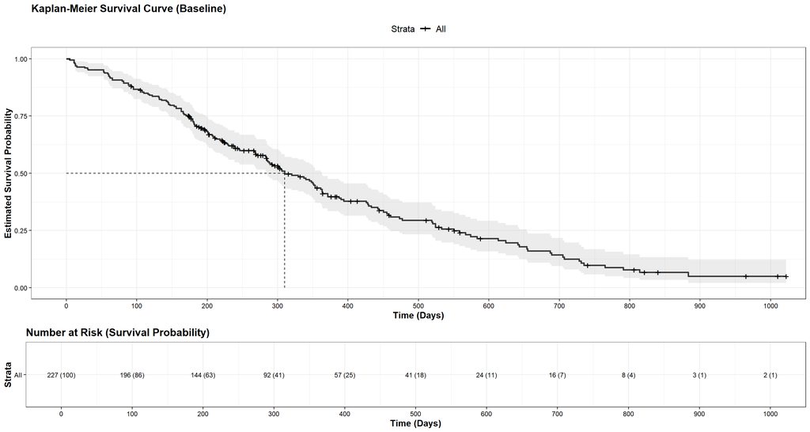

```r
##################################
# Plotting the Kaplan-Meier survival curves
# using the Baseline data
##################################
SurvivalTimeInWeek.KaplanMeier.Baseline <- ggsurvplot(DBP.Analysis.Filtered.Baseline.KaplanMeierEstimates,
                                                     title = "Kaplan-Meier Survival Curve (Baseline)",
                                                     pval = FALSE,
                                                     conf.int = TRUE,
                                                     conf.int.style = "ribbon",
                                                     xlab = "Time (Days)",
                                                     ylab="Estimated Survival Probability",
                                                     break.time.by = 100,
                                                     ggtheme = theme_bw(),
                                                     risk.table = "abs_pct",
                                                     risk.table.title="Number at Risk (Survival Probability)",
                                                     risk.table.y.text.col = FALSE,
                                                     risk.table.y.text = TRUE,
                                                     fontsize = 3,
                                                     ncensor.plot = FALSE,
                                                     surv.median.line = "hv",
                                                     palette = c("#000000"))

ggpar(SurvivalTimeInWeek.KaplanMeier.Baseline,
      font.title = c(14,"bold"),
      font.x = c(12,"bold"),
      font.y = c(12,"bold"),
      font.legend=c(12),
      font.xtickslab=c(9,"black"),
      font.ytickslab=c(9,"black"))
```

```r
##################################
# Computing the Kaplan-Meier survival estimates
# using the Factor Variable
##################################
DBP.Analysis.Filtered.KaplanMeierEstimates <- survfit(Surv(time, status) ~ ph.ecog, data = DBP.Analysis.Filtered)
print(DBP.Analysis.Filtered.KaplanMeierEstimates)
```

```
## Call: survfit(formula = Surv(time, status) ~ ph.ecog, data = DBP.Analysis.Filtered)
##
##                        n events median 0.95LCL 0.95UCL
## ph.ecog=Bedridden     51     45    183     153     288
## ph.ecog=Ambulatory   113     82    306     268     429
## ph.ecog=Asymptomatic  63     37    394     348     574
```

```r
tbl_survfit(DBP.Analysis.Filtered.KaplanMeierEstimates,
            times = c(183,365,548,730,913,1022),
            label_header = "**Day {time}**"
)
```

| **Characteristic** | **Day 183** | **Day 365** | **Day 548** | **Day 730** | **Day 913** | **Day 1022** |
| --- | --- | --- | --- | --- | --- | --- |
| ph.ecog |  |  |  |  |  |  |
| Bedridden | 50% (37%, 66%) | 21% (12%, 37%) | 11% (4.6%, 26%) | 3.6% (0.6%, 22%) | — (—, —) | — (—, —) |
| Ambulatory | 72% (65%, 81%) | 43% (34%, 54%) | 26% (18%, 38%) | 11% (5.8%, 22%) | 6.1% (2.3%, 16%) | 6.1% (2.3%, 16%) |
| Asymptomatic | 84% (76%, 94%) | 54% (41%, 70%) | 37% (25%, 55%) | 19% (9.4%, 40%) | 7.7% (1.5%, 39%) | — (—, —) |

```r
##################################
# Formulating a summary of the Kaplan-Meier survival estimates
# using the Factor Variable
##################################
summary(DBP.Analysis.Filtered.KaplanMeierEstimates)
```

```
## Call: survfit(formula = Surv(time, status) ~ ph.ecog, data = DBP.Analysis.Filtered)
##
##                 ph.ecog=Bedridden
##  time n.risk n.event survival std.err lower 95% CI upper 95% CI
##    11     51       1   0.9804  0.0194      0.94307        1.000
##    12     50       1   0.9608  0.0272      0.90896        1.000
##    13     49       1   0.9412  0.0329      0.87877        1.000
##    26     48       1   0.9216  0.0376      0.85066        0.998
##    30     47       1   0.9020  0.0416      0.82393        0.987
##    53     46       1   0.8824  0.0451      0.79821        0.975
##    54     45       1   0.8627  0.0482      0.77329        0.963
##    61     44       1   0.8431  0.0509      0.74901        0.949
##    65     43       1   0.8235  0.0534      0.72528        0.935
##    81     42       1   0.8039  0.0556      0.70202        0.921
##    93     40       1   0.7838  0.0577      0.67847        0.906
```

[output cut: 152 more lines]

```r
(DBP.Analysis.Filtered.KaplanMeierEstimates.Summary <- summary(DBP.Analysis.Filtered.KaplanMeierEstimates)$table)
```

```
##                      records n.max n.start events    rmean se(rmean) median
## ph.ecog=Bedridden         51    51      51     45 255.7636  30.74032    183
## ph.ecog=Ambulatory       113   113     113     82 384.8410  27.28943    306
## ph.ecog=Asymptomatic      63    63      63     37 465.3131  42.88835    394
##                      0.95LCL 0.95UCL
## ph.ecog=Bedridden        153     288
## ph.ecog=Ambulatory       268     429
## ph.ecog=Asymptomatic     348     574
```

```r
##################################
# Listing the details of the Kaplan-Meier survival estimates
# using the Factor Variable
##################################
(DBP.Analysis.Filtered.KaplanMeierEstimates.Details <- surv_summary(DBP.Analysis.Filtered.KaplanMeierEstimates))
```

```
##     time n.risk n.event n.censor       surv     std.err     upper       lower
## 1     11     51       1        0 0.98039216 0.019802951 1.0000000 0.943069123
## 2     12     50       1        0 0.96078431 0.028289930 1.0000000 0.908961465
## 3     13     49       1        0 0.94117647 0.035007002 1.0000000 0.878765599
## 4     26     48       1        0 0.92156863 0.040850369 0.9983885 0.850659556
## 5     30     47       1        0 0.90196078 0.046165867 0.9873795 0.823931673
## 6     53     46       1        0 0.88235294 0.051130999 0.9753604 0.798214389
## 7     54     45       1        0 0.86274510 0.055851854 0.9625509 0.773288081
## 8     61     44       1        0 0.84313725 0.060398434 0.9490946 0.749009005
## 9     65     43       1        0 0.82352941 0.064820372 0.9350919 0.725277013
## 10    81     42       1        0 0.80392157 0.069154904 0.9206158 0.702019086
## 11    92     41       0        1 0.80392157 0.069154904 0.9206158 0.702019086
## 12    93     40       1        0 0.78382353 0.073643916 0.9055326 0.678472862
## 13    95     39       1        0 0.76372549 0.078090910 0.8900377 0.655339254
## 14   105     38       1        1 0.74362745 0.082519257 0.8741701 0.632579181
```

[output cut: 419 more lines]

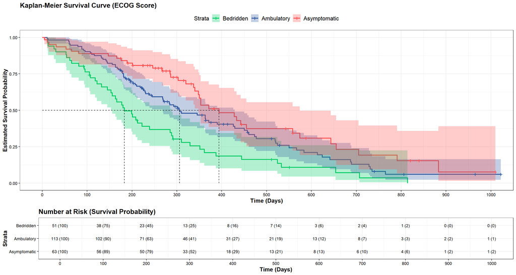

```r
##################################
# Plotting the Kaplan-Meier survival curves
# using the Factor Variable
##################################
SurvivalTimeInWeek.KaplanMeier.ByGroup <- ggsurvplot(DBP.Analysis.Filtered.KaplanMeierEstimates,
                                                     title = "Kaplan-Meier Survival Curve (ECOG Score)",
                                                     pval = FALSE,
                                                     conf.int = TRUE,
                                                     conf.int.style = "ribbon",
                                                     xlab = "Time (Days)",
                                                     ylab="Estimated Survival Probability",
                                                     break.time.by = 100,
                                                     ggtheme = theme_bw(),
                                                     risk.table = "abs_pct",
                                                     risk.table.title="Number at Risk (Survival Probability)",
                                                     risk.table.y.text.col = FALSE,
                                                     risk.table.y.text = TRUE,
                                                     fontsize = 3,
                                                     ncensor.plot = FALSE,
                                                     surv.median.line = "hv",
                                                     legend.labs = c("Bedridden", "Ambulatory", "Asymptomatic"),
                                                     palette = c("#00CC66","#3259A0","#FF5050"))

ggpar(SurvivalTimeInWeek.KaplanMeier.ByGroup,
      font.title = c(14,"bold"),
      font.x = c(12,"bold"),
      font.y = c(12,"bold"),
      font.legend=c(12),
      font.xtickslab=c(9,"black"),
      font.ytickslab=c(9,"black"))
```

### 1.4.3 Log Rank Test

[Log Rank Test](https://link.springer.com/book/10.1007/978-1-4419-6646-9) evaluates the null hypothesis of no difference in survival between two or more independent groups by comparing the entire survival experience. The method involves generating a sequential list of time values corresponding to an event or censoring from two or more independent groups; determining the counts of event-free observations, event and expected events for each time value; calculating the Chi-Square test statistic based on these counts; and evaluating the determined test statistic against the rejection region.

**Code Chunk | Output**

```r
##################################
# Conducting the Log Rank Test
# between the Kaplan-Meier survival estimates
# using the Factor Variable
##################################
(DBP.Analysis.Filtered.LogRankTest <- survdiff(Surv(time, status) ~ ph.ecog, data = DBP.Analysis.Filtered))
```

```
## Call:
## survdiff(formula = Surv(time, status) ~ ph.ecog, data = DBP.Analysis.Filtered)
##
##                        N Observed Expected (O-E)^2/E (O-E)^2/V
## ph.ecog=Bedridden     51       45     26.3   13.2582   15.9641
## ph.ecog=Ambulatory   113       82     83.5    0.0279    0.0573
## ph.ecog=Asymptomatic  63       37     54.2    5.4331    8.2119
##
##  Chisq= 19  on 2 degrees of freedom, p= 8e-05
```

```r
##################################
# Conducting the Post-Hoc Test
# between the Kaplan-Meier survival estimates
# using the Factor Variable
#################################
(DBP.Analysis.Filtered.LogRankTest.PosthocTest <- survminer::pairwise_survdiff(Surv(time, status) ~ ph.ecog, data = DBP.Analysis.Filtered))
```

```
##
##  Pairwise comparisons using Log-Rank test
##
## data:  DBP.Analysis.Filtered and ph.ecog
##
##              Bedridden Ambulatory
## Ambulatory   0.0039    -
## Asymptomatic 9e-05     0.0630
##
## P value adjustment method: BH
```

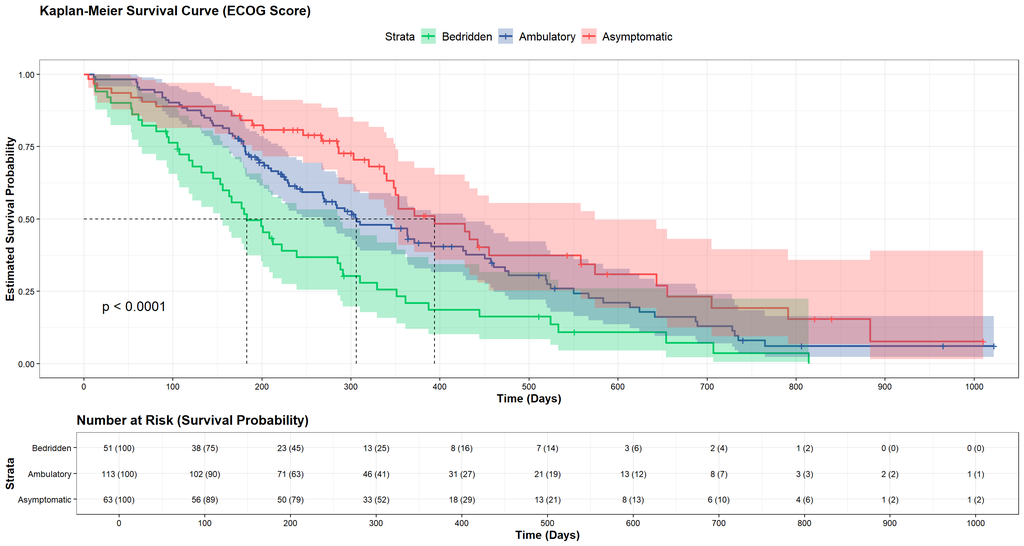

```r
##################################
# Plotting the Kaplan-Meier survival curves
# using the Factor Variable
##################################
SurvivalTimeInWeek.KaplanMeier.ByGroup <- ggsurvplot(DBP.Analysis.Filtered.KaplanMeierEstimates,
                                                     title = "Kaplan-Meier Survival Curve (ECOG Score)",
                                                     pval = TRUE,
                                                     conf.int = TRUE,
                                                     conf.int.style = "ribbon",
                                                     xlab = "Time (Days)",
                                                     ylab="Estimated Survival Probability",
                                                     break.time.by = 100,
                                                     ggtheme = theme_bw(),
                                                     risk.table = "abs_pct",
                                                     risk.table.title="Number at Risk (Survival Probability)",
                                                     risk.table.y.text.col = FALSE,
                                                     risk.table.y.text = TRUE,
                                                     fontsize = 3,
                                                     ncensor.plot = FALSE,
                                                     surv.median.line = "hv",
                                                     legend.labs = c("Bedridden", "Ambulatory", "Asymptomatic"),
                                                     palette = c("#00CC66","#3259A0","#FF5050"))

ggpar(SurvivalTimeInWeek.KaplanMeier.ByGroup,
      font.title = c(14,"bold"),
      font.x = c(12,"bold"),
      font.y = c(12,"bold"),
      font.legend=c(12),
      font.xtickslab=c(9,"black"),
      font.ytickslab=c(9,"black"))
```

## 1.5 Model Development Summary

[Cox Proportional Hazards Regression](https://rss.onlinelibrary.wiley.com/doi/abs/10.1111/j.2517-6161.1972.tb00899.x) examines the relationship between a hazard function and a set of covariates by assuming that predictors act multiplicatively on the hazard function without any explicit assumption of its distributional form. The model is semi-parametric because while the baseline hazard can take any form, the covariates enter the model linearly.  
[Concordance Index](https://jamanetwork.com/journals/jama/article-abstract/372568) is a rank correlation measure between a predictor and a possibly censored outcome with an event or censoring indicator. In survival analysis, a pair of patients is called concordant if the risk of the event predicted by a model is lower for the patient who experiences the event at a later time point. The concordance probability (C-index) is the frequency of concordant pairs among all pairs of subjects which can be used to measure and compare the discrimination power of risk prediction models.  
[Residual Analysis for Model Assumption Diagnostics](https://link.springer.com/book/10.1007/978-1-4419-6646-9) assesses whether a fitted Cox Proportional Hazards Regression model adequately describes the data using various residuals to test the proportional hazards assumption, examine influential observations (or outliers) and detect nonlinearity in the relationship between the log hazard and the covariates. Schoenfeld residuals are calculated by regressing the scaled and weighted Martingale residuals on the model covariates. These help evaluate the proportional hazards assumption by examining the relationship between the residuals and time for each covariate. A significant correlation between Schoenfeld residuals and time suggests a violation of the model assumptions. Deviance residuals are derived from the log partial likelihood estimation during regression. These measure the difference between the observed event status and the predicted event probability. Deviance residuals are more sensitive to the shape of the hazard function and can help identify departures from the model assumptions.  
Cox proportional hazards regression analysis involving the response variable time, factor variable ph.ecog and covariate variables sex and age showed that :  
**[A]** A cox proportional hazards regression model applied on the response variable time and factor variable ph.ecog which includes the covariate variable sex but excludes the covariate variable age was determined with the most optimal fit during stepwise variable selection. Furthermore, the aforementioned model was considered the most appropriate as the final survival model since the addition of the covariate variable sex significantly improved model fit (p<0.001, Likelihood Ratio Test). However, the further inclusion of an interaction term ph.ecog * sex into the model did not show any significant improvement to model fit (p=0.789, Likelihood Ratio Test).  
**[B]** Using the final survival model controlled for sex, association between ph.ecog and survival time time was statistically significant with:  
**[B.1]** An estimated hazard ratio of 0.58 (95% CI 0.40, 0.84; p=0.004, Cox Proportional Hazards Model Wald Test) for ph.ecog=Ambulatory (lower hazard and higher survival rate for advanced lung cancer patients with physician-rated ECOG score = 1) relative to ph.ecog=Bedridden (higher hazard and lower survival rate for advanced lung cancer patients with physician-rated ECOG score = 2 or 3)  
**[B.2]** An estimated hazard ratio of 0.38 (95% CI 0.25, 0.59; p<0.001, Cox Proportional Hazards Model Wald Test) for ph.ecog=Asymptomatic (lower hazard and higher survival rate for advanced lung cancer patients with physician-rated ECOG score = 0) relative to ph.ecog=Bedridden (higher hazard and lower survival rate for advanced lung cancer patients with physician-rated ECOG score = 2 or 3)  
**[C]** Using the final survival model controlled for ph.ecog, association between sex and survival time time was statistically significant with an estimated hazard ratio of 0.58 (95% CI 0.42, 0.80; p=0.001, Cox Proportional Hazards Model Wald Test) for sex=Female (lower hazard and higher survival rate for advanced lung cancer patients who are females) relative to sex=Male (higher hazard and lower survival rate for advanced lung cancer patients who are males).  
**[D]** The estimated Harrel’s concordance index (proportion of advanced lung cancer patients that the model can correctly order in terms of survival times when adjusted for censoring) for the final survival model was determined to be relatively satisfactory at 0.64 (optimistic) and 0.63 (optimism-corrected after a 500-cycle internal bootstrap validation).  
**[E]** The scaled Schoenfield residuals showed random patterns when plotted against time indicating no violation of the proportional hazards assumption. The proportional hazards assumption was further supported by the non-significant relationship between the scaled Schoenfield residuals and time based from the global (p=0.1514) and individual (p=0.2188 for ph.ecpg, 0.1001 for sex ) statistical test results.  
**[F]** The deviance residuals did not show any severely influential observations when plotted against the observations and the dfbeta residuals were reasonably symmetrical when plotted against the observations - all indicating a fairly good model fit for the final survival model. Due to the absence of a numeric covariate, no fitted line with lowess function of the martingale residuals obtained for the null cox model was obtained.

### 1.5.1 Univariate Cox Proportional Hazards Model

**Code Chunk | Output**

```r
##################################
# Formulating a Univariate Cox Proportional Hazards Model
# independently for the Factor Variable
##################################
(DBP.Analysis.UnivariateCoxPH.PhEcog <- coxph(Surv(time, status) ~ ph.ecog, data = DBP.Analysis.Filtered))
```

```
## Call:
## coxph(formula = Surv(time, status) ~ ph.ecog, data = DBP.Analysis.Filtered)
##
##                        coef exp(coef) se(coef)      z        p
## ph.ecogAmbulatory   -0.5628    0.5696   0.1863 -3.021  0.00252
## ph.ecogAsymptomatic -0.9309    0.3942   0.2235 -4.166 3.11e-05
##
## Likelihood ratio test=17.33  on 2 df, p=0.0001722
## n= 227, number of events= 164
```

```r
summary(DBP.Analysis.UnivariateCoxPH.PhEcog)
```

```
## Call:
## coxph(formula = Surv(time, status) ~ ph.ecog, data = DBP.Analysis.Filtered)
##
##   n= 227, number of events= 164
##
##                        coef exp(coef) se(coef)      z Pr(>|z|)
## ph.ecogAmbulatory   -0.5628    0.5696   0.1863 -3.021  0.00252 **
## ph.ecogAsymptomatic -0.9309    0.3942   0.2235 -4.166 3.11e-05 ***
## ---
## Signif. codes:  0 '***' 0.001 '**' 0.01 '*' 0.05 '.' 0.1 ' ' 1
##
##                     exp(coef) exp(-coef) lower .95 upper .95
## ph.ecogAmbulatory      0.5696      1.755    0.3954    0.8207
## ph.ecogAsymptomatic    0.3942      2.537    0.2544    0.6108
##
## Concordance= 0.604  (se = 0.024 )
## Likelihood ratio test= 17.33  on 2 df,   p=2e-04
## Wald test            = 18.17  on 2 df,   p=1e-04
## Score (logrank) test = 19  on 2 df,   p=7e-05
```

```r
tbl_regression(DBP.Analysis.UnivariateCoxPH.PhEcog,
               exponentiate = TRUE)
```

| **Characteristic** | **HR**<sup>1</sup> | **95% CI**<sup>1</sup> | **p-value** |
| --- | --- | --- | --- |
| ph.ecog |  |  |  |
| Bedridden | — | — |  |
| Ambulatory | 0.57 | 0.40, 0.82 | 0.003 |
| Asymptomatic | 0.39 | 0.25, 0.61 | <0.001 |

<sup>1</sup> HR = Hazard Ratio, CI = Confidence Interval

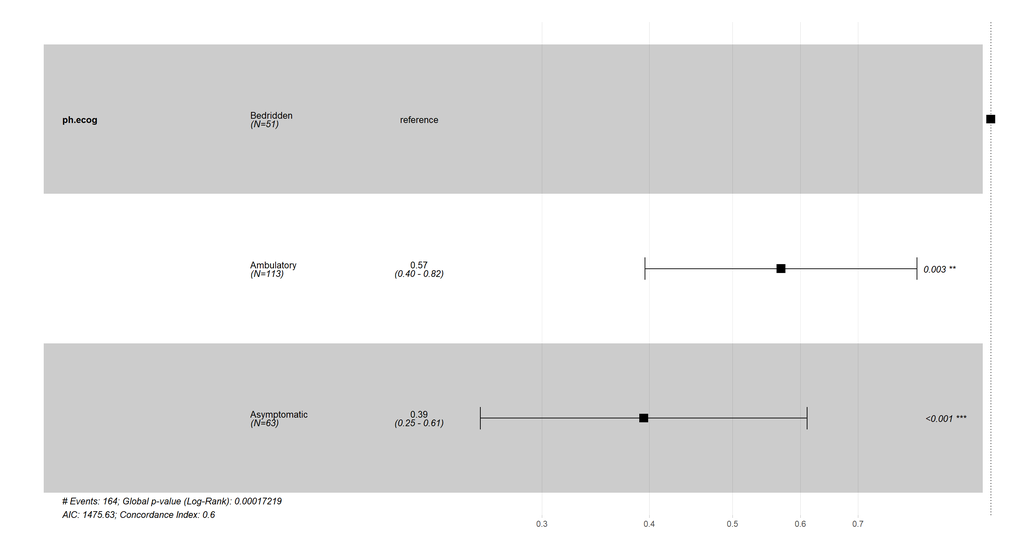

```r
(ggforest(DBP.Analysis.UnivariateCoxPH.PhEcog,
          data=DBP.Analysis.Filtered,
          main = "",
          fontsize = 0.9))
```

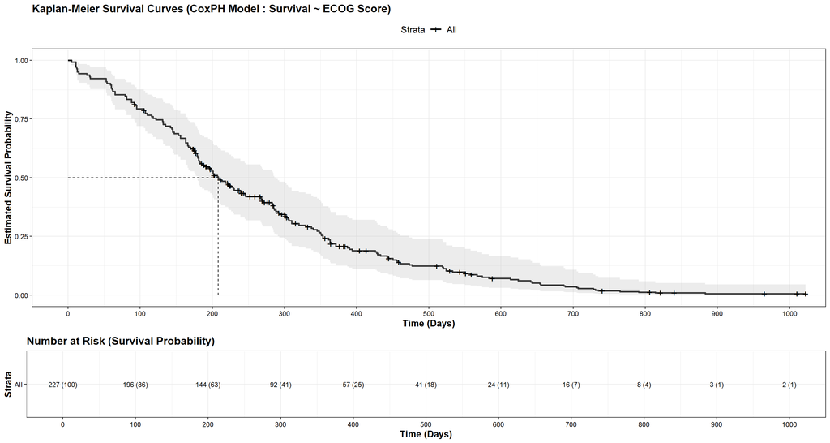

```r
##################################
# Plotting the Kaplan-Meier survival curves
# for the formulated Univariate Cox Proportional Hazards Model
# involving the Factor Variable
##################################
DBP.Analysis.UnivariateCoxPH.PhEcog.KaplanMeierEstimates <- survfit(DBP.Analysis.UnivariateCoxPH.PhEcog, data = DBP.Analysis.Filtered)

SurvivalTimeInWeek.KaplanMeier.UnivariateCoxPH.PhEcog <- ggsurvplot(DBP.Analysis.UnivariateCoxPH.PhEcog.KaplanMeierEstimates,
                                                     title = "Kaplan-Meier Survival Curves (CoxPH Model : Survival ~ ECOG Score)",
                                                     pval = FALSE,
                                                     conf.int = TRUE,
                                                     conf.int.style = "ribbon",
                                                     xlab = "Time (Days)",
                                                     ylab="Estimated Survival Probability",
                                                     break.time.by = 100,
                                                     ggtheme = theme_bw(),
                                                     risk.table = "abs_pct",
                                                     risk.table.title="Number at Risk (Survival Probability)",
                                                     risk.table.y.text.col = FALSE,
                                                     risk.table.y.text = TRUE,
                                                     fontsize = 3,
                                                     ncensor.plot = FALSE,
                                                     surv.median.line = "hv",
                                                     palette = c("#000000"))

ggpar(SurvivalTimeInWeek.KaplanMeier.UnivariateCoxPH.PhEcog,
      font.title = c(14,"bold"),
      font.x = c(12,"bold"),
      font.y = c(12,"bold"),
      font.legend=c(12),
      font.xtickslab=c(9,"black"),
      font.ytickslab=c(9,"black"))
```

```r
##################################
# Formulating a Univariate Cox Proportional Hazards Model
# independently for the Covariate Variable
##################################
(DBP.Analysis.UnivariateCoxPH.Sex <- coxph(Surv(time, status) ~ sex, data = DBP.Analysis.Filtered))
```

```
## Call:
## coxph(formula = Surv(time, status) ~ sex, data = DBP.Analysis.Filtered)
##
##              coef exp(coef) se(coef)      z       p
## sexFemale -0.5237    0.5923   0.1674 -3.128 0.00176
##
## Likelihood ratio test=10.3  on 1 df, p=0.001331
## n= 227, number of events= 164
```

```r
summary(DBP.Analysis.UnivariateCoxPH.Sex)
```

```
## Call:
## coxph(formula = Surv(time, status) ~ sex, data = DBP.Analysis.Filtered)
##
##   n= 227, number of events= 164
##
##              coef exp(coef) se(coef)      z Pr(>|z|)
## sexFemale -0.5237    0.5923   0.1674 -3.128  0.00176 **
## ---
## Signif. codes:  0 '***' 0.001 '**' 0.01 '*' 0.05 '.' 0.1 ' ' 1
##
##           exp(coef) exp(-coef) lower .95 upper .95
## sexFemale    0.5923      1.688    0.4266    0.8224
##
## Concordance= 0.577  (se = 0.021 )
## Likelihood ratio test= 10.3  on 1 df,   p=0.001
## Wald test            = 9.78  on 1 df,   p=0.002
## Score (logrank) test = 10.01  on 1 df,   p=0.002
```

```r
tbl_regression(DBP.Analysis.UnivariateCoxPH.Sex,
               exponentiate = TRUE)
```

| **Characteristic** | **HR**<sup>1</sup> | **95% CI**<sup>1</sup> | **p-value** |
| --- | --- | --- | --- |
| sex |  |  |  |
| Male | — | — |  |
| Female | 0.59 | 0.43, 0.82 | 0.002 |

<sup>1</sup> HR = Hazard Ratio, CI = Confidence Interval

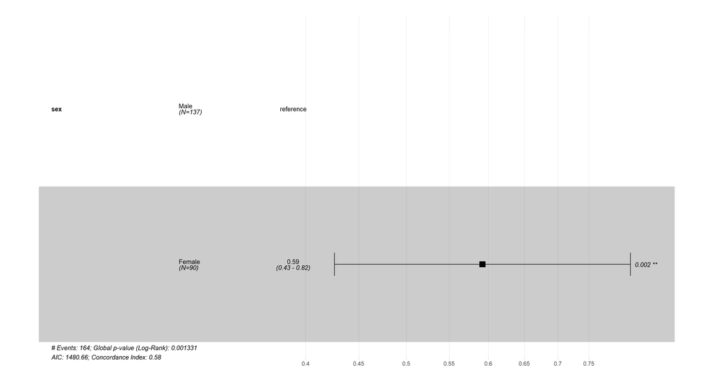

```r
(ggforest(DBP.Analysis.UnivariateCoxPH.Sex,
          data=DBP.Analysis.Filtered,
          main = "",
          fontsize = 0.9))
```

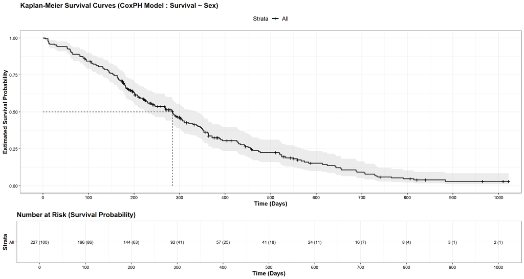

```r
##################################
# Plotting the Kaplan-Meier survival curves
# for the formulated Univariate Cox Proportional Hazards Model
# involving the Covariate Variable
##################################
DBP.Analysis.UnivariateCoxPH.Sex.KaplanMeierEstimates <- survfit(DBP.Analysis.UnivariateCoxPH.Sex, data = DBP.Analysis.Filtered)

SurvivalTimeInWeek.KaplanMeier.UnivariateCoxPH.Sex <- ggsurvplot(DBP.Analysis.UnivariateCoxPH.Sex.KaplanMeierEstimates,
                                                     title = "Kaplan-Meier Survival Curves (CoxPH Model : Survival ~ Sex)",
                                                     pval = FALSE,
                                                     conf.int = TRUE,
                                                     conf.int.style = "ribbon",
                                                     xlab = "Time (Days)",
                                                     ylab="Estimated Survival Probability",
                                                     break.time.by = 100,
                                                     ggtheme = theme_bw(),
                                                     risk.table = "abs_pct",
                                                     risk.table.title="Number at Risk (Survival Probability)",
                                                     risk.table.y.text.col = FALSE,
                                                     risk.table.y.text = TRUE,
                                                     fontsize = 3,
                                                     ncensor.plot = FALSE,
                                                     surv.median.line = "hv",
                                                     palette = c("#000000"))

ggpar(SurvivalTimeInWeek.KaplanMeier.UnivariateCoxPH.Sex,
      font.title = c(14,"bold"),
      font.x = c(12,"bold"),
      font.y = c(12,"bold"),
      font.legend=c(12),
      font.xtickslab=c(9,"black"),
      font.ytickslab=c(9,"black"))
```

```r
##################################
# Formulating a Univariate Cox Proportional Hazards Model
# independently for the Covariate Variable
##################################
(DBP.Analysis.UnivariateCoxPH.Age <- coxph(Surv(time, status) ~ age, data = DBP.Analysis.Filtered))
```

```
## Call:
## coxph(formula = Surv(time, status) ~ age, data = DBP.Analysis.Filtered)
##
##         coef exp(coef) se(coef)     z      p
## age 0.018969  1.019150 0.009231 2.055 0.0399
##
## Likelihood ratio test=4.33  on 1 df, p=0.03754
## n= 227, number of events= 164
```

```r
summary(DBP.Analysis.UnivariateCoxPH.Age)
```

```
## Call:
## coxph(formula = Surv(time, status) ~ age, data = DBP.Analysis.Filtered)
##
##   n= 227, number of events= 164
##
##         coef exp(coef) se(coef)     z Pr(>|z|)
## age 0.018969  1.019150 0.009231 2.055   0.0399 *
## ---
## Signif. codes:  0 '***' 0.001 '**' 0.01 '*' 0.05 '.' 0.1 ' ' 1
##
##     exp(coef) exp(-coef) lower .95 upper .95
## age     1.019     0.9812     1.001     1.038
##
## Concordance= 0.551  (se = 0.025 )
## Likelihood ratio test= 4.33  on 1 df,   p=0.04
## Wald test            = 4.22  on 1 df,   p=0.04
## Score (logrank) test = 4.24  on 1 df,   p=0.04
```

```r
tbl_regression(DBP.Analysis.UnivariateCoxPH.Age,
               exponentiate = TRUE)
```

| **Characteristic** | **HR**<sup>1</sup> | **95% CI**<sup>1</sup> | **p-value** |
| --- | --- | --- | --- |
| age | 1.02 | 1.00, 1.04 | 0.040 |

<sup>1</sup> HR = Hazard Ratio, CI = Confidence Interval

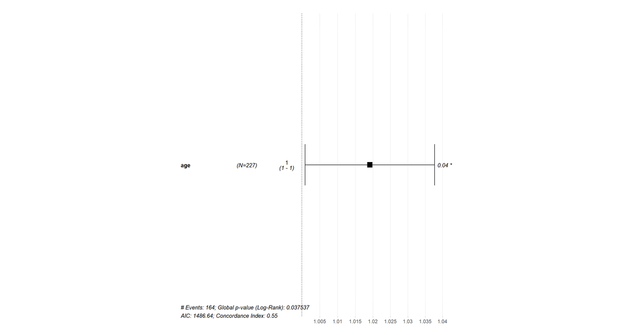

```r
(ggforest(DBP.Analysis.UnivariateCoxPH.Age,
          data=DBP.Analysis.Filtered,
          main = "",
          fontsize = 0.9))
```

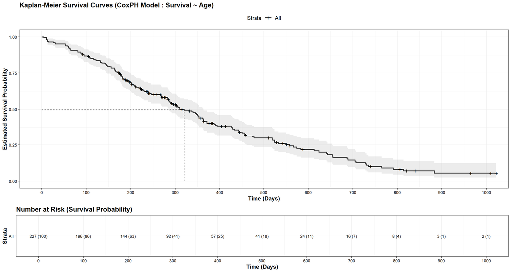

```r
##################################
# Plotting the Kaplan-Meier survival curves
# for the formulated Univariate Cox Proportional Hazards Model
# involving the Covariate Variable
##################################
DBP.Analysis.UnivariateCoxPH.Age.KaplanMeierEstimates <- survfit(DBP.Analysis.UnivariateCoxPH.Age, data = DBP.Analysis.Filtered)

SurvivalTimeInWeek.KaplanMeier.UnivariateCoxPH.Age <- ggsurvplot(DBP.Analysis.UnivariateCoxPH.Age.KaplanMeierEstimates,
                                                     title = "Kaplan-Meier Survival Curves (CoxPH Model : Survival ~ Age)",
                                                     pval = FALSE,
                                                     conf.int = TRUE,
                                                     conf.int.style = "ribbon",
                                                     xlab = "Time (Days)",
                                                     ylab="Estimated Survival Probability",
                                                     break.time.by = 100,
                                                     ggtheme = theme_bw(),
                                                     risk.table = "abs_pct",
                                                     risk.table.title="Number at Risk (Survival Probability)",
                                                     risk.table.y.text.col = FALSE,
                                                     risk.table.y.text = TRUE,
                                                     fontsize = 3,
                                                     ncensor.plot = FALSE,
                                                     surv.median.line = "hv",
                                                     palette = c("#000000"))

ggpar(SurvivalTimeInWeek.KaplanMeier.UnivariateCoxPH.Age,
      font.title = c(14,"bold"),
      font.x = c(12,"bold"),
      font.y = c(12,"bold"),
      font.legend=c(12),
      font.xtickslab=c(9,"black"),
      font.ytickslab=c(9,"black"))
```

```r
##################################
# Formulating a Univariate Cox Proportional Hazards Model
# individually for the Factor and Covariate Variables
##################################
tbl_survfit(
  list(survfit(Surv(time, status) ~ 1, data = DBP.Analysis.Filtered),
    survfit(Surv(time, status) ~ ph.ecog, data = DBP.Analysis.Filtered),
    survfit(Surv(time, status) ~ sex, data = DBP.Analysis.Filtered),
        survfit(Surv(time, status) ~ age, data = DBP.Analysis.Filtered)),
  probs = 0.5,
  label_header = "**Median Survival**") %>%
  add_n() %>%
  add_nevent()
```

| **Characteristic** | **N** | **Event N** | **Median Survival** |
| --- | --- | --- | --- |
| Overall | 227 | 164 | 310 (285, 363) |
| ph.ecog | 227 | 164 |  |
| Bedridden |  |  | 183 (153, 288) |
| Ambulatory |  |  | 306 (268, 429) |
| Asymptomatic |  |  | 394 (348, 574) |
| sex | 227 | 164 |  |
| Male |  |  | 270 (218, 320) |
| Female |  |  | 426 (348, 550) |
| age | 227 | 164 |  |
| 39 |  |  | — (—, —) |
| 40 |  |  | 132 (—, —) |
| 41 |  |  | — (—, —) |
| 42 |  |  | — (—, —) |
| 43 |  |  | — (—, —) |
| 44 |  |  | 268 (181, —) |
| 45 |  |  | — (—, —) |
| 46 |  |  | 320 (—, —) |
| 47 |  |  | 353 (—, —) |
| 48 |  |  | 419 (223, —) |
| 49 |  |  | 147 (81, —) |
| 50 |  |  | 239 (131, —) |
| 51 |  |  | 705 (—, —) |
| 52 |  |  | 179 (81, —) |
| 53 |  |  | 226 (202, —) |
| 54 |  |  | 491 (163, —) |
| 55 |  |  | 308 (156, —) |
| 56 |  |  | 363 (197, —) |
| 57 |  |  | 245 (170, —) |
| 58 |  |  | 371 (348, —) |
| 59 |  |  | 433 (293, —) |
| 60 |  |  | 387 (145, —) |
| 61 |  |  | 166 (147, —) |
| 62 |  |  | 291 (105, —) |
| 63 |  |  | 519 (189, —) |
| 64 |  |  | 477 (110, —) |
| 65 |  |  | 174 (60, —) |
| 66 |  |  | 288 (156, —) |
| 67 |  |  | 230 (208, —) |
| 68 |  |  | 455 (310, —) |
| 69 |  |  | 450 (329, —) |
| 70 |  |  | 460 (229, —) |
| 71 |  |  | 332 (284, —) |
| 72 |  |  | 270 (54, —) |
| 73 |  |  | 164 (59, —) |
| 74 |  |  | 306 (93, —) |
| 75 |  |  | 397 (201, —) |
| 76 |  |  | 116 (95, —) |
| 77 |  |  | — (—, —) |
| 80 |  |  | 323 (283, —) |
| 81 |  |  | 11 (—, —) |
| 82 |  |  | 31 (—, —) |

### 1.5.2 Multivariate Cox Proportional Hazards Model

**Code Chunk | Output**

```r
##################################
# Formulating a Multivariate Cox Proportional Hazards Model
# with both the Factor and Covariate Variables
##################################
(DBP.Analysis.MultivariateCoxPH.PhEcogSexAge <- coxph(Surv(time, status) ~ ph.ecog + sex + age, data = DBP.Analysis.Filtered))
```

```
## Call:
## coxph(formula = Surv(time, status) ~ ph.ecog + sex + age, data = DBP.Analysis.Filtered)
##
##                          coef exp(coef)  se(coef)      z       p
## ph.ecogAmbulatory   -0.506291  0.602727  0.188454 -2.687 0.00722
## ph.ecogAsymptomatic -0.915752  0.400215  0.227042 -4.033 5.5e-05
## sexFemale           -0.551322  0.576188  0.167987 -3.282 0.00103
## age                  0.011031  1.011092  0.009297  1.186 0.23544
##
## Likelihood ratio test=30.08  on 4 df, p=4.704e-06
## n= 227, number of events= 164
```

```r
summary(DBP.Analysis.MultivariateCoxPH.PhEcogSexAge)
```

```
## Call:
## coxph(formula = Surv(time, status) ~ ph.ecog + sex + age, data = DBP.Analysis.Filtered)
##
##   n= 227, number of events= 164
##
##                          coef exp(coef)  se(coef)      z Pr(>|z|)
## ph.ecogAmbulatory   -0.506291  0.602727  0.188454 -2.687  0.00722 **
## ph.ecogAsymptomatic -0.915752  0.400215  0.227042 -4.033  5.5e-05 ***
## sexFemale           -0.551322  0.576188  0.167987 -3.282  0.00103 **
## age                  0.011031  1.011092  0.009297  1.186  0.23544
## ---
## Signif. codes:  0 '***' 0.001 '**' 0.01 '*' 0.05 '.' 0.1 ' ' 1
##
##                     exp(coef) exp(-coef) lower .95 upper .95
## ph.ecogAmbulatory      0.6027      1.659    0.4166    0.8720
## ph.ecogAsymptomatic    0.4002      2.499    0.2565    0.6245
## sexFemale              0.5762      1.736    0.4145    0.8009
## age                    1.0111      0.989    0.9928    1.0297
##
## Concordance= 0.637  (se = 0.025 )
## Likelihood ratio test= 30.08  on 4 df,   p=5e-06
## Wald test            = 29.77  on 4 df,   p=5e-06
## Score (logrank) test = 30.94  on 4 df,   p=3e-06
```

```r
tbl_regression(DBP.Analysis.MultivariateCoxPH.PhEcogSexAge,
               exponentiate = TRUE)
```

| **Characteristic** | **HR**<sup>1</sup> | **95% CI**<sup>1</sup> | **p-value** |
| --- | --- | --- | --- |
| ph.ecog |  |  |  |
| Bedridden | — | — |  |
| Ambulatory | 0.60 | 0.42, 0.87 | 0.007 |
| Asymptomatic | 0.40 | 0.26, 0.62 | <0.001 |
| sex |  |  |  |
| Male | — | — |  |
| Female | 0.58 | 0.41, 0.80 | 0.001 |
| age | 1.01 | 0.99, 1.03 | 0.2 |

<sup>1</sup> HR = Hazard Ratio, CI = Confidence Interval

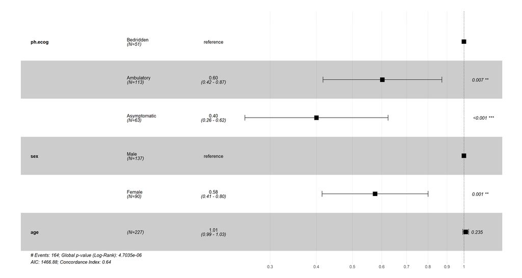

```r
(DBP.Analysis.MultivariateCoxPH.DBP.Analysis.MultivariateCoxPH.PhEcogSexAge.ForestPlot <- ggforest(DBP.Analysis.MultivariateCoxPH.PhEcogSexAge,
          data=DBP.Analysis.Filtered,
          main = "",
          fontsize = 0.9))
```

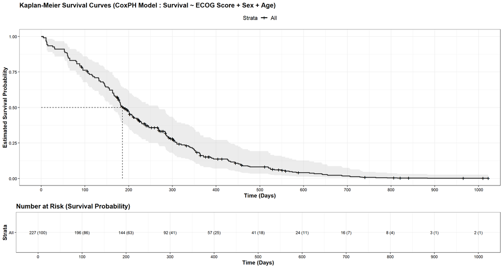

```r
##################################
# Plotting the Kaplan-Meier survival curves
# for the formulated Multivariate Cox Proportional Hazards Model
# involving the Factor and Covariate variables
##################################
DBP.Analysis.MultivariateCoxPH.PhEcogSexAge.KaplanMeierEstimates <- survfit(DBP.Analysis.MultivariateCoxPH.PhEcogSexAge , data = DBP.Analysis.Filtered)

SurvivalTimeInWeek.KaplanMeier.MultivariateCoxPH.PhEcogSexAge <- ggsurvplot(DBP.Analysis.MultivariateCoxPH.PhEcogSexAge.KaplanMeierEstimates,
                                                     title = "Kaplan-Meier Survival Curves (CoxPH Model : Survival ~ ECOG Score + Sex + Age)",
                                                     pval = FALSE,
                                                     conf.int = TRUE,
                                                     conf.int.style = "ribbon",
                                                     xlab = "Time (Days)",
                                                     ylab="Estimated Survival Probability",
                                                     break.time.by = 100,
                                                     ggtheme = theme_bw(),
                                                     risk.table = "abs_pct",
                                                     risk.table.title="Number at Risk (Survival Probability)",
                                                     risk.table.y.text.col = FALSE,
                                                     risk.table.y.text = TRUE,
                                                     fontsize = 3,
                                                     ncensor.plot = FALSE,
                                                     surv.median.line = "hv",
                                                     palette = c("#000000"))

ggpar(SurvivalTimeInWeek.KaplanMeier.MultivariateCoxPH.PhEcogSexAge,
      font.title = c(14,"bold"),
      font.x = c(12,"bold"),
      font.y = c(12,"bold"),
      font.legend=c(12),
      font.xtickslab=c(9,"black"),
      font.ytickslab=c(9,"black"))
```

```r
##################################
# Formulating a Multivariate Cox Proportional Hazards Model
# with both the Factor and Covariate Variables
# including their interaction
##################################
(DBP.Analysis.MultivariateCoxPH.PhEcogSexAge.WithInteraction <- coxph(Surv(time, status) ~ ph.ecog + sex + age + ph.ecog*sex*age, data = DBP.Analysis.Filtered))
```

```
## Call:
## coxph(formula = Surv(time, status) ~ ph.ecog + sex + age + ph.ecog *
##     sex * age, data = DBP.Analysis.Filtered)
##
##                                         coef  exp(coef)   se(coef)      z
## ph.ecogAmbulatory                  2.430e+00  1.136e+01  2.064e+00  1.177
## ph.ecogAsymptomatic               -1.392e+00  2.486e-01  2.547e+00 -0.546
## sexFemale                          7.319e+00  1.509e+03  2.746e+00  2.665
## age                                4.669e-02  1.048e+00  2.842e-02  1.643
## ph.ecogAmbulatory:sexFemale       -7.406e+00  6.073e-04  3.180e+00 -2.329
## ph.ecogAsymptomatic:sexFemale     -7.486e+00  5.610e-04  4.250e+00 -1.761
## ph.ecogAmbulatory:age             -4.524e-02  9.558e-01  3.178e-02 -1.424
## ph.ecogAsymptomatic:age            8.315e-03  1.008e+00  3.895e-02  0.213
## sexFemale:age                     -1.151e-01  8.912e-01  4.139e-02 -2.782
## ph.ecogAmbulatory:sexFemale:age    1.065e-01  1.112e+00  4.896e-02  2.176
## ph.ecogAsymptomatic:sexFemale:age  1.102e-01  1.116e+00  6.622e-02  1.664
##                                        p
## ph.ecogAmbulatory                 0.2390
## ph.ecogAsymptomatic               0.5848
## sexFemale                         0.0077
## age                               0.1004
## ph.ecogAmbulatory:sexFemale       0.0199
## ph.ecogAsymptomatic:sexFemale     0.0782
## ph.ecogAmbulatory:age             0.1545
## ph.ecogAsymptomatic:age           0.8309
## sexFemale:age                     0.0054
## ph.ecogAmbulatory:sexFemale:age   0.0295
## ph.ecogAsymptomatic:sexFemale:age 0.0961
##
## Likelihood ratio test=42.43  on 11 df, p=1.362e-05
## n= 227, number of events= 164
```

```r
summary(DBP.Analysis.MultivariateCoxPH.PhEcogSexAge.WithInteraction)
```

```
## Call:
## coxph(formula = Surv(time, status) ~ ph.ecog + sex + age + ph.ecog *
##     sex * age, data = DBP.Analysis.Filtered)
##
##   n= 227, number of events= 164
##
##                                         coef  exp(coef)   se(coef)      z
## ph.ecogAmbulatory                  2.430e+00  1.136e+01  2.064e+00  1.177
## ph.ecogAsymptomatic               -1.392e+00  2.486e-01  2.547e+00 -0.546
## sexFemale                          7.319e+00  1.509e+03  2.746e+00  2.665
## age                                4.669e-02  1.048e+00  2.842e-02  1.643
## ph.ecogAmbulatory:sexFemale       -7.406e+00  6.073e-04  3.180e+00 -2.329
## ph.ecogAsymptomatic:sexFemale     -7.486e+00  5.610e-04  4.250e+00 -1.761
## ph.ecogAmbulatory:age             -4.524e-02  9.558e-01  3.178e-02 -1.424
## ph.ecogAsymptomatic:age            8.315e-03  1.008e+00  3.895e-02  0.213
## sexFemale:age                     -1.151e-01  8.912e-01  4.139e-02 -2.782
## ph.ecogAmbulatory:sexFemale:age    1.065e-01  1.112e+00  4.896e-02  2.176
## ph.ecogAsymptomatic:sexFemale:age  1.102e-01  1.116e+00  6.622e-02  1.664
##                                   Pr(>|z|)
## ph.ecogAmbulatory                   0.2390
## ph.ecogAsymptomatic                 0.5848
## sexFemale                           0.0077 **
## age                                 0.1004
## ph.ecogAmbulatory:sexFemale         0.0199 *
## ph.ecogAsymptomatic:sexFemale       0.0782 .
## ph.ecogAmbulatory:age               0.1545
## ph.ecogAsymptomatic:age             0.8309
## sexFemale:age                       0.0054 **
## ph.ecogAmbulatory:sexFemale:age     0.0295 *
## ph.ecogAsymptomatic:sexFemale:age   0.0961 .
## ---
## Signif. codes:  0 '***' 0.001 '**' 0.01 '*' 0.05 '.' 0.1 ' ' 1
##
##                                   exp(coef) exp(-coef) lower .95 upper .95
## ph.ecogAmbulatory                 1.136e+01  8.804e-02 1.989e-01 6.488e+02
## ph.ecogAsymptomatic               2.486e-01  4.022e+00 1.688e-03 3.663e+01
## sexFemale                         1.509e+03  6.627e-04 6.935e+00 3.284e+05
## age                               1.048e+00  9.544e-01 9.910e-01 1.108e+00
## ph.ecogAmbulatory:sexFemale       6.073e-04  1.647e+03 1.192e-06 3.095e-01
## ph.ecogAsymptomatic:sexFemale     5.610e-04  1.782e+03 1.352e-07 2.327e+00
## ph.ecogAmbulatory:age             9.558e-01  1.046e+00 8.981e-01 1.017e+00
## ph.ecogAsymptomatic:age           1.008e+00  9.917e-01 9.342e-01 1.088e+00
## sexFemale:age                     8.912e-01  1.122e+00 8.218e-01 9.665e-01
## ph.ecogAmbulatory:sexFemale:age   1.112e+00  8.989e-01 1.011e+00 1.224e+00
## ph.ecogAsymptomatic:sexFemale:age 1.116e+00  8.957e-01 9.806e-01 1.271e+00
##
## Concordance= 0.662  (se = 0.024 )
## Likelihood ratio test= 42.43  on 11 df,   p=1e-05
## Wald test            = 41.85  on 11 df,   p=2e-05
## Score (logrank) test = 47.09  on 11 df,   p=2e-06
```

```r
tbl_regression(DBP.Analysis.MultivariateCoxPH.PhEcogSexAge.WithInteraction,
               exponentiate = TRUE)
```

| **Characteristic** | **HR**<sup>1</sup> | **95% CI**<sup>1</sup> | **p-value** |
| --- | --- | --- | --- |
| ph.ecog |  |  |  |
| Bedridden | — | — |  |
| Ambulatory | 11.4 | 0.20, 649 | 0.2 |
| Asymptomatic | 0.25 | 0.00, 36.6 | 0.6 |
| sex |  |  |  |
| Male | — | — |  |
| Female | 1,509 | 6.93, 328,387 | 0.008 |
| age | 1.05 | 0.99, 1.11 | 0.10 |
| ph.ecog * sex |  |  |  |
| Ambulatory * Female | 0.00 | 0.00, 0.31 | 0.020 |
| Asymptomatic * Female | 0.00 | 0.00, 2.33 | 0.078 |
| ph.ecog * age |  |  |  |
| Ambulatory * age | 0.96 | 0.90, 1.02 | 0.2 |
| Asymptomatic * age | 1.01 | 0.93, 1.09 | 0.8 |
| sex * age |  |  |  |
| Female * age | 0.89 | 0.82, 0.97 | 0.005 |
| ph.ecog * sex * age |  |  |  |
| Ambulatory * Female * age | 1.11 | 1.01, 1.22 | 0.030 |
| Asymptomatic * Female * age | 1.12 | 0.98, 1.27 | 0.10 |

<sup>1</sup> HR = Hazard Ratio, CI = Confidence Interval

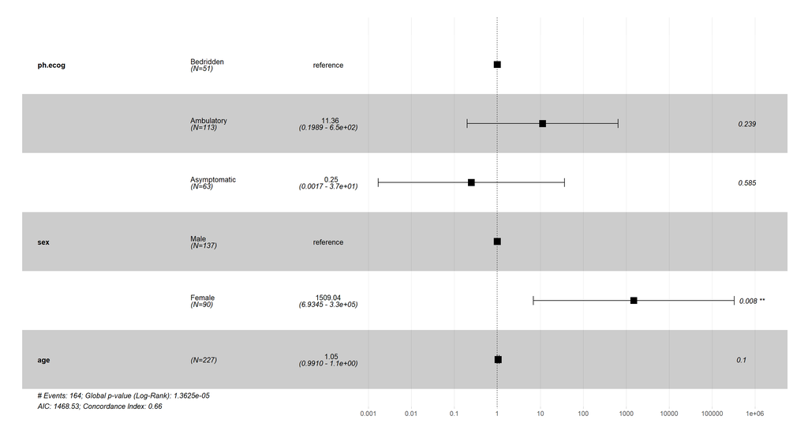

```r
(DBP.Analysis.MultivariateCoxPH.PhEcogSexAge.WithInteraction.ForestPlot <- ggforest(DBP.Analysis.MultivariateCoxPH.PhEcogSexAge.WithInteraction,
          data=DBP.Analysis.Filtered,
          main = "",
          fontsize = 0.9))
```

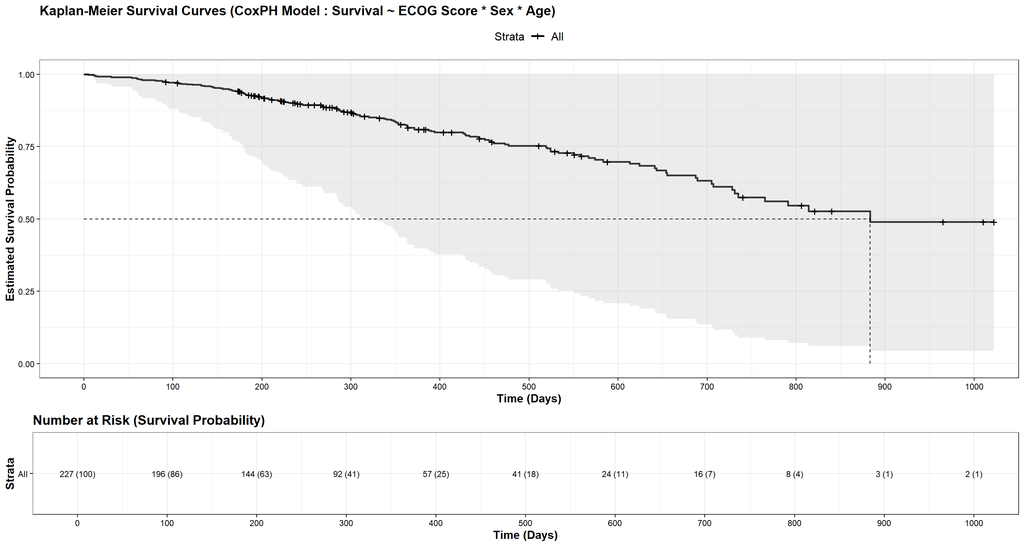

```r
##################################
# Plotting the Kaplan-Meier survival curves
# for the formulated Multivariate Cox Proportional Hazards Model
# involving the Factor and Covariate variables
# including their interaction
##################################
DBP.Analysis.MultivariateCoxPH.PhEcogSexAge.WithInteraction.KaplanMeierEstimates <- survfit(DBP.Analysis.MultivariateCoxPH.PhEcogSexAge.WithInteraction, data = DBP.Analysis.Filtered)

SurvivalTimeInWeek.KaplanMeier.MultivariateCoxPH.PhEcogSexAge.WithInteraction <- ggsurvplot(DBP.Analysis.MultivariateCoxPH.PhEcogSexAge.WithInteraction.KaplanMeierEstimates,
                                                     title = "Kaplan-Meier Survival Curves (CoxPH Model : Survival ~ ECOG Score * Sex * Age)",
                                                     pval = FALSE,
                                                     conf.int = TRUE,
                                                     conf.int.style = "ribbon",
                                                     xlab = "Time (Days)",
                                                     ylab="Estimated Survival Probability",
                                                     break.time.by = 100,
                                                     ggtheme = theme_bw(),
                                                     risk.table = "abs_pct",
                                                     risk.table.title="Number at Risk (Survival Probability)",
                                                     risk.table.y.text.col = FALSE,
                                                     risk.table.y.text = TRUE,
                                                     fontsize = 3,
                                                     ncensor.plot = FALSE,
                                                     surv.median.line = "hv",
                                                     palette = c("#000000"))

ggpar(SurvivalTimeInWeek.KaplanMeier.MultivariateCoxPH.PhEcogSexAge.WithInteraction,
      font.title = c(14,"bold"),
      font.x = c(12,"bold"),
      font.y = c(12,"bold"),
      font.legend=c(12),
      font.xtickslab=c(9,"black"),
      font.ytickslab=c(9,"black"))
```

```r
##################################
# Formulating a Multivariate Cox Proportional Hazards Model
# with both the Factor and Covariate Variables
##################################
(DBP.Analysis.MultivariateCoxPH.PhEcogSex <- coxph(Surv(time, status) ~ ph.ecog + sex , data = DBP.Analysis.Filtered))
```

```
## Call:
## coxph(formula = Surv(time, status) ~ ph.ecog + sex, data = DBP.Analysis.Filtered)
##
##                        coef exp(coef) se(coef)      z        p
## ph.ecogAmbulatory   -0.5433    0.5808   0.1861 -2.919  0.00351
## ph.ecogAsymptomatic -0.9611    0.3825   0.2237 -4.297 1.73e-05
## sexFemale           -0.5503    0.5768   0.1679 -3.277  0.00105
##
## Likelihood ratio test=28.66  on 3 df, p=2.643e-06
## n= 227, number of events= 164
```

```r
summary(DBP.Analysis.MultivariateCoxPH.PhEcogSex)
```

```
## Call:
## coxph(formula = Surv(time, status) ~ ph.ecog + sex, data = DBP.Analysis.Filtered)
##
##   n= 227, number of events= 164
##
##                        coef exp(coef) se(coef)      z Pr(>|z|)
## ph.ecogAmbulatory   -0.5433    0.5808   0.1861 -2.919  0.00351 **
## ph.ecogAsymptomatic -0.9611    0.3825   0.2237 -4.297 1.73e-05 ***
## sexFemale           -0.5503    0.5768   0.1679 -3.277  0.00105 **
## ---
## Signif. codes:  0 '***' 0.001 '**' 0.01 '*' 0.05 '.' 0.1 ' ' 1
##
##                     exp(coef) exp(-coef) lower .95 upper .95
## ph.ecogAmbulatory      0.5808      1.722    0.4033    0.8365
## ph.ecogAsymptomatic    0.3825      2.615    0.2467    0.5929
## sexFemale              0.5768      1.734    0.4151    0.8016
##
## Concordance= 0.642  (se = 0.025 )
## Likelihood ratio test= 28.66  on 3 df,   p=3e-06
## Wald test            = 28.99  on 3 df,   p=2e-06
## Score (logrank) test = 30.04  on 3 df,   p=1e-06
```

```r
tbl_regression(DBP.Analysis.MultivariateCoxPH.PhEcogSex,
               exponentiate = TRUE)
```

| **Characteristic** | **HR**<sup>1</sup> | **95% CI**<sup>1</sup> | **p-value** |
| --- | --- | --- | --- |
| ph.ecog |  |  |  |
| Bedridden | — | — |  |
| Ambulatory | 0.58 | 0.40, 0.84 | 0.004 |
| Asymptomatic | 0.38 | 0.25, 0.59 | <0.001 |
| sex |  |  |  |
| Male | — | — |  |
| Female | 0.58 | 0.42, 0.80 | 0.001 |

<sup>1</sup> HR = Hazard Ratio, CI = Confidence Interval

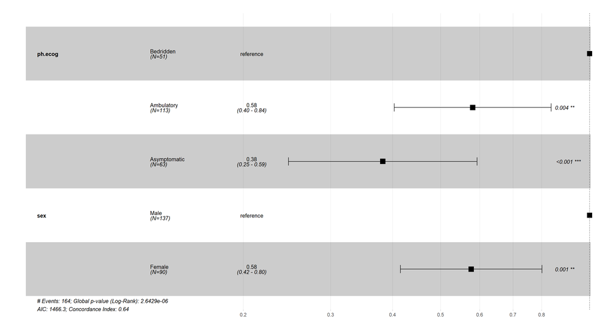

```r
(DBP.Analysis.MultivariateCoxPH.DBP.Analysis.MultivariateCoxPH.PhEcogSex.ForestPlot <- ggforest(DBP.Analysis.MultivariateCoxPH.PhEcogSex,
          data=DBP.Analysis.Filtered,
          main = "",
          fontsize = 0.9))
```

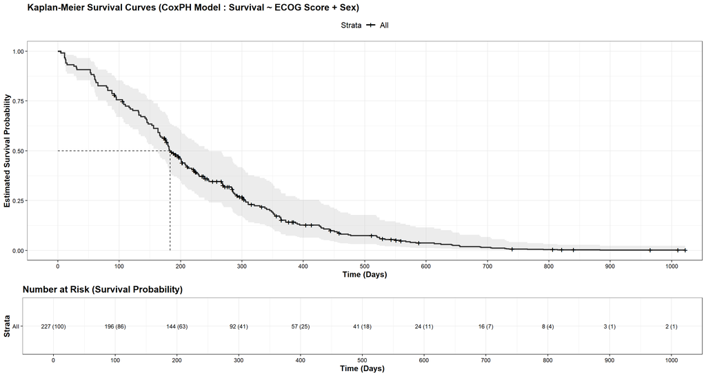

```r
##################################
# Plotting the Kaplan-Meier survival curves
# for the formulated Multivariate Cox Proportional Hazards Model
# involving the Factor and Covariate variables
##################################
DBP.Analysis.MultivariateCoxPH.PhEcogSex.KaplanMeierEstimates <- survfit(DBP.Analysis.MultivariateCoxPH.PhEcogSex , data = DBP.Analysis.Filtered)

SurvivalTimeInWeek.KaplanMeier.MultivariateCoxPH.PhEcogSex <- ggsurvplot(DBP.Analysis.MultivariateCoxPH.PhEcogSex.KaplanMeierEstimates,
                                                     title = "Kaplan-Meier Survival Curves (CoxPH Model : Survival ~ ECOG Score + Sex)",
                                                     pval = FALSE,
                                                     conf.int = TRUE,
                                                     conf.int.style = "ribbon",
                                                     xlab = "Time (Days)",
                                                     ylab="Estimated Survival Probability",
                                                     break.time.by = 100,
                                                     ggtheme = theme_bw(),
                                                     risk.table = "abs_pct",
                                                     risk.table.title="Number at Risk (Survival Probability)",
                                                     risk.table.y.text.col = FALSE,
                                                     risk.table.y.text = TRUE,
                                                     fontsize = 3,
                                                     ncensor.plot = FALSE,
                                                     surv.median.line = "hv",
                                                     palette = c("#000000"))

ggpar(SurvivalTimeInWeek.KaplanMeier.MultivariateCoxPH.PhEcogSex,
      font.title = c(14,"bold"),
      font.x = c(12,"bold"),
      font.y = c(12,"bold"),
      font.legend=c(12),
      font.xtickslab=c(9,"black"),
      font.ytickslab=c(9,"black"))
```

```r
##################################
# Formulating a Multivariate Cox Proportional Hazards Model
# with both the Factor and Covariate Variables
# including their interaction
##################################
(DBP.Analysis.MultivariateCoxPH.PhEcogSex.WithInteraction <- coxph(Surv(time, status) ~ ph.ecog + sex + ph.ecog*sex, data = DBP.Analysis.Filtered))
```

```
## Call:
## coxph(formula = Surv(time, status) ~ ph.ecog + sex + ph.ecog *
##     sex, data = DBP.Analysis.Filtered)
##
##                                  coef exp(coef) se(coef)      z       p
## ph.ecogAmbulatory             -0.4669    0.6269   0.2312 -2.020 0.04339
## ph.ecogAsymptomatic           -0.8692    0.4193   0.2667 -3.259 0.00112
## sexFemale                     -0.3724    0.6891   0.3130 -1.190 0.23419
## ph.ecogAmbulatory:sexFemale   -0.2258    0.7979   0.3927 -0.575 0.56533
## ph.ecogAsymptomatic:sexFemale -0.3055    0.7367   0.4945 -0.618 0.53670
##
## Likelihood ratio test=29.13  on 5 df, p=2.186e-05
## n= 227, number of events= 164
```

```r
summary(DBP.Analysis.MultivariateCoxPH.PhEcogSex.WithInteraction)
```

```
## Call:
## coxph(formula = Surv(time, status) ~ ph.ecog + sex + ph.ecog *
##     sex, data = DBP.Analysis.Filtered)
##
##   n= 227, number of events= 164
##
##                                  coef exp(coef) se(coef)      z Pr(>|z|)
## ph.ecogAmbulatory             -0.4669    0.6269   0.2312 -2.020  0.04339 *
## ph.ecogAsymptomatic           -0.8692    0.4193   0.2667 -3.259  0.00112 **
## sexFemale                     -0.3724    0.6891   0.3130 -1.190  0.23419
## ph.ecogAmbulatory:sexFemale   -0.2258    0.7979   0.3927 -0.575  0.56533
## ph.ecogAsymptomatic:sexFemale -0.3055    0.7367   0.4945 -0.618  0.53670
## ---
## Signif. codes:  0 '***' 0.001 '**' 0.01 '*' 0.05 '.' 0.1 ' ' 1
##
##                               exp(coef) exp(-coef) lower .95 upper .95
## ph.ecogAmbulatory                0.6269      1.595    0.3985    0.9862
## ph.ecogAsymptomatic              0.4193      2.385    0.2486    0.7072
## sexFemale                        0.6891      1.451    0.3731    1.2727
## ph.ecogAmbulatory:sexFemale      0.7979      1.253    0.3695    1.7228
## ph.ecogAsymptomatic:sexFemale    0.7367      1.357    0.2795    1.9420
##
## Concordance= 0.643  (se = 0.025 )
## Likelihood ratio test= 29.13  on 5 df,   p=2e-05
## Wald test            = 28.01  on 5 df,   p=4e-05
## Score (logrank) test = 30.3  on 5 df,   p=1e-05
```

```r
tbl_regression(DBP.Analysis.MultivariateCoxPH.PhEcogSex.WithInteraction,
               exponentiate = TRUE)
```

| **Characteristic** | **HR**<sup>1</sup> | **95% CI**<sup>1</sup> | **p-value** |
| --- | --- | --- | --- |
| ph.ecog |  |  |  |
| Bedridden | — | — |  |
| Ambulatory | 0.63 | 0.40, 0.99 | 0.043 |
| Asymptomatic | 0.42 | 0.25, 0.71 | 0.001 |
| sex |  |  |  |
| Male | — | — |  |
| Female | 0.69 | 0.37, 1.27 | 0.2 |
| ph.ecog * sex |  |  |  |
| Ambulatory * Female | 0.80 | 0.37, 1.72 | 0.6 |
| Asymptomatic * Female | 0.74 | 0.28, 1.94 | 0.5 |

<sup>1</sup> HR = Hazard Ratio, CI = Confidence Interval

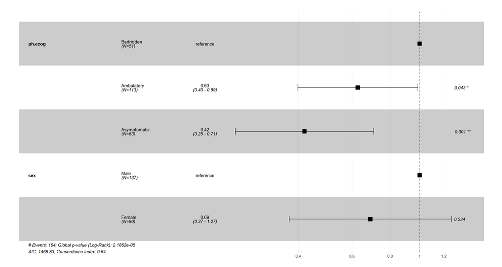

```r
(DBP.Analysis.MultivariateCoxPH.PhEcogSex.WithInteraction.ForestPlot <- ggforest(DBP.Analysis.MultivariateCoxPH.PhEcogSex.WithInteraction,
          data=DBP.Analysis.Filtered,
          main = "",
          fontsize = 0.9))
```

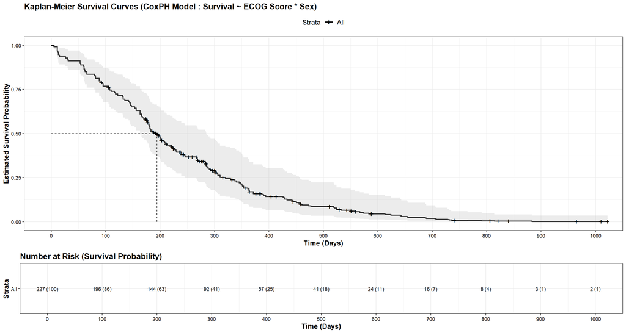

```r
##################################
# Plotting the Kaplan-Meier survival curves
# for the formulated Multivariate Cox Proportional Hazards Model
# involving the Factor and Covariate variables
# including their interaction
##################################
DBP.Analysis.MultivariateCoxPH.PhEcogSex.WithInteraction.KaplanMeierEstimates <- survfit(DBP.Analysis.MultivariateCoxPH.PhEcogSex.WithInteraction, data = DBP.Analysis.Filtered)

SurvivalTimeInWeek.KaplanMeier.MultivariateCoxPH.PhEcogSex.WithInteraction <- ggsurvplot(DBP.Analysis.MultivariateCoxPH.PhEcogSex.WithInteraction.KaplanMeierEstimates,
                                                     title = "Kaplan-Meier Survival Curves (CoxPH Model : Survival ~ ECOG Score * Sex)",
                                                     pval = FALSE,
                                                     conf.int = TRUE,
                                                     conf.int.style = "ribbon",
                                                     xlab = "Time (Days)",
                                                     ylab="Estimated Survival Probability",
                                                     break.time.by = 100,
                                                     ggtheme = theme_bw(),
                                                     risk.table = "abs_pct",
                                                     risk.table.title="Number at Risk (Survival Probability)",
                                                     risk.table.y.text.col = FALSE,
                                                     risk.table.y.text = TRUE,
                                                     fontsize = 3,
                                                     ncensor.plot = FALSE,
                                                     surv.median.line = "hv",
                                                     palette = c("#000000"))

ggpar(SurvivalTimeInWeek.KaplanMeier.MultivariateCoxPH.PhEcogSex.WithInteraction,
      font.title = c(14,"bold"),
      font.x = c(12,"bold"),
      font.y = c(12,"bold"),
      font.legend=c(12),
      font.xtickslab=c(9,"black"),
      font.ytickslab=c(9,"black"))
```

```r
##################################
# Formulating complete and reduced
# Multivariate Cox Proportional Hazards Models
# involving the Factor and Covariate Variables
##################################
DBP.Analysis.SurvivalResponse <- "Surv(time, status)"
DBP.Analysis.SurvivalPredictorComplete <- c("ph.ecog", "sex", "age")
DBP.Analysis.SurvivalPredictorReduced <- c("ph.ecog", "sex")

DBP.Analysis.CoxPHModelSummary <- DBP.Analysis.Filtered %>%
  finalfit(DBP.Analysis.SurvivalResponse,
           DBP.Analysis.SurvivalPredictorComplete,
           DBP.Analysis.SurvivalPredictorReduced,
           keep_models = TRUE,
           add_dependent_label = FALSE) %>%
  rename("Overall Survival" = label) %>%
  rename(" " = levels) %>%
  rename("  " = all)

kable(DBP.Analysis.CoxPHModelSummary)
```

|  | Overall Survival |  |  | HR (univariable) | HR (multivariable full) | HR (multivariable) |
| --- | --- | --- | --- | --- | --- | --- |
| 4 | ph.ecog | Bedridden | 51 (22.5) | - | - | - |
| 2 |  | Ambulatory | 113 (49.8) | 0.57 (0.40-0.82, p=0.003) | 0.60 (0.42-0.87, p=0.007) | 0.58 (0.40-0.84, p=0.004) |
| 3 |  | Asymptomatic | 63 (27.8) | 0.39 (0.25-0.61, p<0.001) | 0.40 (0.26-0.62, p<0.001) | 0.38 (0.25-0.59, p<0.001) |
| 6 | sex | Male | 137 (60.4) | - | - | - |
| 5 |  | Female | 90 (39.6) | 0.59 (0.43-0.82, p=0.002) | 0.58 (0.41-0.80, p=0.001) | 0.58 (0.42-0.80, p=0.001) |
| 1 | age | Mean (SD) | 62.5 (9.1) | 1.02 (1.00-1.04, p=0.040) | 1.01 (0.99-1.03, p=0.235) | - |

### 1.5.3 Model Selection

**Code Chunk | Output**

```r
##################################
# Applying Stepwise Variable Selection
##################################
DBP.Analysis.MultivariateCoxPH.StepwiseSelection <- stepAIC(DBP.Analysis.MultivariateCoxPH.PhEcogSexAge,
                      direction = "both",
                      trace = TRUE)
```

```
## Start:  AIC=1466.88
## Surv(time, status) ~ ph.ecog + sex + age
##
##           Df    AIC
## - age      1 1466.3
## <none>       1466.9
## - sex      1 1476.2
## - ph.ecog  2 1479.1
##
## Step:  AIC=1466.3
## Surv(time, status) ~ ph.ecog + sex
##
##           Df    AIC
## <none>       1466.3
## + age      1 1466.9
## - sex      1 1475.6
## - ph.ecog  2 1480.7
```

```r
summary(DBP.Analysis.MultivariateCoxPH.StepwiseSelection)
```

```
## Call:
## coxph(formula = Surv(time, status) ~ ph.ecog + sex, data = DBP.Analysis.Filtered)
##
##   n= 227, number of events= 164
##
##                        coef exp(coef) se(coef)      z Pr(>|z|)
## ph.ecogAmbulatory   -0.5433    0.5808   0.1861 -2.919  0.00351 **
## ph.ecogAsymptomatic -0.9611    0.3825   0.2237 -4.297 1.73e-05 ***
## sexFemale           -0.5503    0.5768   0.1679 -3.277  0.00105 **
## ---
## Signif. codes:  0 '***' 0.001 '**' 0.01 '*' 0.05 '.' 0.1 ' ' 1
##
##                     exp(coef) exp(-coef) lower .95 upper .95
## ph.ecogAmbulatory      0.5808      1.722    0.4033    0.8365
## ph.ecogAsymptomatic    0.3825      2.615    0.2467    0.5929
## sexFemale              0.5768      1.734    0.4151    0.8016
##
## Concordance= 0.642  (se = 0.025 )
## Likelihood ratio test= 28.66  on 3 df,   p=3e-06
## Wald test            = 28.99  on 3 df,   p=2e-06
## Score (logrank) test = 30.04  on 3 df,   p=1e-06
```

```r
##################################
# Reusing formulated models
##################################
summary(DBP.Analysis.UnivariateCoxPH.PhEcog)
```

```
## Call:
## coxph(formula = Surv(time, status) ~ ph.ecog, data = DBP.Analysis.Filtered)
##
##   n= 227, number of events= 164
##
##                        coef exp(coef) se(coef)      z Pr(>|z|)
## ph.ecogAmbulatory   -0.5628    0.5696   0.1863 -3.021  0.00252 **
## ph.ecogAsymptomatic -0.9309    0.3942   0.2235 -4.166 3.11e-05 ***
## ---
## Signif. codes:  0 '***' 0.001 '**' 0.01 '*' 0.05 '.' 0.1 ' ' 1
##
##                     exp(coef) exp(-coef) lower .95 upper .95
## ph.ecogAmbulatory      0.5696      1.755    0.3954    0.8207
## ph.ecogAsymptomatic    0.3942      2.537    0.2544    0.6108
##
## Concordance= 0.604  (se = 0.024 )
## Likelihood ratio test= 17.33  on 2 df,   p=2e-04
## Wald test            = 18.17  on 2 df,   p=1e-04
## Score (logrank) test = 19  on 2 df,   p=7e-05
```

```r
summary(DBP.Analysis.MultivariateCoxPH.PhEcogSex)
```

```
## Call:
## coxph(formula = Surv(time, status) ~ ph.ecog + sex, data = DBP.Analysis.Filtered)
##
##   n= 227, number of events= 164
##
##                        coef exp(coef) se(coef)      z Pr(>|z|)
## ph.ecogAmbulatory   -0.5433    0.5808   0.1861 -2.919  0.00351 **
## ph.ecogAsymptomatic -0.9611    0.3825   0.2237 -4.297 1.73e-05 ***
## sexFemale           -0.5503    0.5768   0.1679 -3.277  0.00105 **
## ---
## Signif. codes:  0 '***' 0.001 '**' 0.01 '*' 0.05 '.' 0.1 ' ' 1
##
##                     exp(coef) exp(-coef) lower .95 upper .95
## ph.ecogAmbulatory      0.5808      1.722    0.4033    0.8365
## ph.ecogAsymptomatic    0.3825      2.615    0.2467    0.5929
## sexFemale              0.5768      1.734    0.4151    0.8016
##
## Concordance= 0.642  (se = 0.025 )
## Likelihood ratio test= 28.66  on 3 df,   p=3e-06
## Wald test            = 28.99  on 3 df,   p=2e-06
## Score (logrank) test = 30.04  on 3 df,   p=1e-06
```

```r
summary(DBP.Analysis.MultivariateCoxPH.PhEcogSex.WithInteraction)
```

```
## Call:
## coxph(formula = Surv(time, status) ~ ph.ecog + sex + ph.ecog *
##     sex, data = DBP.Analysis.Filtered)
##
##   n= 227, number of events= 164
##
##                                  coef exp(coef) se(coef)      z Pr(>|z|)
## ph.ecogAmbulatory             -0.4669    0.6269   0.2312 -2.020  0.04339 *
## ph.ecogAsymptomatic           -0.8692    0.4193   0.2667 -3.259  0.00112 **
## sexFemale                     -0.3724    0.6891   0.3130 -1.190  0.23419
## ph.ecogAmbulatory:sexFemale   -0.2258    0.7979   0.3927 -0.575  0.56533
## ph.ecogAsymptomatic:sexFemale -0.3055    0.7367   0.4945 -0.618  0.53670
## ---
## Signif. codes:  0 '***' 0.001 '**' 0.01 '*' 0.05 '.' 0.1 ' ' 1
##
##                               exp(coef) exp(-coef) lower .95 upper .95
## ph.ecogAmbulatory                0.6269      1.595    0.3985    0.9862
## ph.ecogAsymptomatic              0.4193      2.385    0.2486    0.7072
## sexFemale                        0.6891      1.451    0.3731    1.2727
## ph.ecogAmbulatory:sexFemale      0.7979      1.253    0.3695    1.7228
## ph.ecogAsymptomatic:sexFemale    0.7367      1.357    0.2795    1.9420
##
## Concordance= 0.643  (se = 0.025 )
## Likelihood ratio test= 29.13  on 5 df,   p=2e-05
## Wald test            = 28.01  on 5 df,   p=4e-05
## Score (logrank) test = 30.3  on 5 df,   p=1e-05
```

```r
##################################
# Formulating the linear predictors
# for the formulated Univariate Cox Proportional Hazards Models
##################################
DBP.Analysis.Filtered$LP.Univariate.PhEcog <- predict(DBP.Analysis.UnivariateCoxPH.PhEcog, type = "lp")

##################################
# Formulating the linear predictors
# for the formulated Multivariate Cox Proportional Hazards Models
##################################
DBP.Analysis.Filtered$LP.Multivariate.PhEcogSex <- predict(DBP.Analysis.MultivariateCoxPH.PhEcogSex, type = "lp")
DBP.Analysis.Filtered$LP.Multivariate.PhEcogSex.WithInteraction <- predict(DBP.Analysis.MultivariateCoxPH.PhEcogSex.WithInteraction, type = "lp")

##################################
# Conducting a likelihood ratio test between nested models
# including the formulated Multivariate Cox Proportional Hazards Models
# involving the Factor variable only
# and both Factor and Covariate variables
##################################
(LikelihoodRatioTest.CoxPHPhEcog.CoxPHPhEcogSex <- anova(DBP.Analysis.UnivariateCoxPH.PhEcog,
      DBP.Analysis.MultivariateCoxPH.PhEcogSex,
      test="LRT"))
```

```
## Analysis of Deviance Table
##  Cox model: response is  Surv(time, status)
##  Model 1: ~ ph.ecog
##  Model 2: ~ ph.ecog + sex
##    loglik  Chisq Df Pr(>|Chi|)
## 1 -735.81
## 2 -730.15 11.324  1  0.0007652 ***
## ---
## Signif. codes:  0 '***' 0.001 '**' 0.01 '*' 0.05 '.' 0.1 ' ' 1
```

```r
##################################
# Conducting a likelihood ratio test between nested models
# including the formulated Multivariate Cox Proportional Hazards Models
# involving both Factor and Covariate variables only
# and both Factor and Covariate variables including their interaction
##################################
(LikelihoodRatioTest.CoxPHPhEcogSex.CoxPHPhEcogSexWithInteraction <- anova(DBP.Analysis.MultivariateCoxPH.PhEcogSex,
      DBP.Analysis.MultivariateCoxPH.PhEcogSex.WithInteraction,
      test="LRT"))
```

```
## Analysis of Deviance Table
##  Cox model: response is  Surv(time, status)
##  Model 1: ~ ph.ecog + sex
##  Model 2: ~ ph.ecog + sex + ph.ecog * sex
##    loglik  Chisq Df Pr(>|Chi|)
## 1 -730.15
## 2 -729.92 0.4727  2     0.7895
```

### 1.5.4 Model Performance Validation

**Code Chunk | Output**

```r
##################################
# Measuring the Harrel's Concordance Index
# for the formulated Univariate Cox Proportional Hazards Model
# involving the Factor variable
##################################
rcorrcens(formula = Surv(time, status) ~ I(-1 * LP.Univariate.PhEcog), data = DBP.Analysis.Filtered)
```

```
##
## Somers' Rank Correlation for Censored Data    Response variable:Surv(time, status)
##
##                                  C   Dxy  aDxy    SD    Z P   n
## I(-1 * LP.Univariate.PhEcog) 0.604 0.208 0.208 0.048 4.35 0 227
```

```r
LP.Univariate.PhEcog.Concordance <- survConcordance(Surv(time, status) ~ LP.Univariate.PhEcog,
                                               data = DBP.Analysis.Filtered)

(LP.Univariate.PhEcog.Concordance$concordance)
```

```
## concordant
##  0.6039571
```

```r
DBP.Analysis.UnivariateCoxPH.PhEcog.Validation <- cph(Surv(time, status) ~ ph.ecog,
                                                     x=TRUE,
                                                     y=TRUE,
                                                     data = DBP.Analysis.Filtered)

set.seed (88888888)
DBP.Analysis.UnivariateCoxPH.PhEcog.Validation.Summary <- validate(DBP.Analysis.UnivariateCoxPH.PhEcog.Validation, B =500)

(DBP.Analysis.UnivariateCoxPH.PhEcog.ConcordanceIndex.Optimistic <- (DBP.Analysis.UnivariateCoxPH.PhEcog.Validation.Summary[1,1]/2)+0.50)
```

```
## [1] 0.6039571
```

```r
(DBP.Analysis.UnivariateCoxPH.PhEcog.ConcordanceIndex.OptimismCorrected <- (DBP.Analysis.UnivariateCoxPH.PhEcog.Validation.Summary[1,5]/2)+0.50)
```

```
## [1] 0.6035354
```

```r
##################################
# Measuring the Harrel's Concordance Index
# for the formulated Multivariate Cox Proportional Hazards Model
# involving the Factor and Covariate variables
##################################
rcorrcens(formula = Surv(time, status) ~ I(-1 * LP.Multivariate.PhEcogSex), data = DBP.Analysis.Filtered)
```

```
##
## Somers' Rank Correlation for Censored Data    Response variable:Surv(time, status)
##
##                                       C   Dxy  aDxy    SD    Z P   n
## I(-1 * LP.Multivariate.PhEcogSex) 0.642 0.284 0.284 0.049 5.74 0 227
```

```r
LP.Multivariate.PhEcogSex.Concordance <- survConcordance(Surv(time, status) ~ LP.Multivariate.PhEcogSex,
                                                        data = DBP.Analysis.Filtered)

(LP.Multivariate.PhEcogSex.Concordance$concordance)
```

```
## concordant
##  0.6418861
```

```r
DBP.Analysis.Multivariate.PhEcogSex.Validation <- cph(Surv(time, status) ~ ph.ecog + sex,
                                                     x=TRUE,
                                                     y=TRUE,
                                                     data = DBP.Analysis.Filtered)

set.seed (88888888)
DBP.Analysis.Multivariate.PhEcogSex.Validation.Summary <- validate(DBP.Analysis.Multivariate.PhEcogSex.Validation, B =500)

(DBP.Analysis.Multivariate.PhEcogSex.ConcordanceIndex.Optimistic <- (DBP.Analysis.Multivariate.PhEcogSex.Validation.Summary[1,1]/2)+0.50)
```

```
## [1] 0.6418861
```

```r
(DBP.Analysis.Multivariate.PhEcogSex.ConcordanceIndex.OptimismCorrected <- (DBP.Analysis.Multivariate.PhEcogSex.Validation.Summary[1,5]/2)+0.50)
```

```
## [1] 0.6355095
```

```r
##################################
# Measuring the Harrel's Concordance Index
# for the formulated Multivariate Cox Proportional Hazards Model
# involving the Factor and Covariate variables
# including their interaction
##################################
rcorrcens(formula = Surv(time, status) ~ I(-1 * LP.Multivariate.PhEcogSex.WithInteraction), data = DBP.Analysis.Filtered)
```

```
##
## Somers' Rank Correlation for Censored Data    Response variable:Surv(time, status)
##
##                                                       C   Dxy  aDxy    SD    Z
## I(-1 * LP.Multivariate.PhEcogSex.WithInteraction) 0.643 0.286 0.286 0.049 5.83
##                                                   P   n
## I(-1 * LP.Multivariate.PhEcogSex.WithInteraction) 0 227
```

```r
LP.Multivariate.PhEcogSex.WithInteraction.Concordance <- survConcordance(Surv(time, status) ~ LP.Multivariate.PhEcogSex.WithInteraction, data = DBP.Analysis.Filtered)

(LP.Multivariate.PhEcogSex.WithInteraction.Concordance$concordance)
```

```
## concordant
##  0.6432001
```

```r
DBP.Analysis.Multivariate.PhEcogSex.WithInteraction.Validation <- cph(Surv(time, status) ~ ph.ecog + sex + ph.ecog*sex,
                                                     x=TRUE,
                                                     y=TRUE,
                                                     data = DBP.Analysis.Filtered)

set.seed (88888888)
DBP.Analysis.Multivariate.PhEcogSex.WithInteraction.Validation.Summary <- validate(DBP.Analysis.Multivariate.PhEcogSex.WithInteraction.Validation, B =500)

(DBP.Analysis.Multivariate.PhEcogSex.WithInteraction.ConcordanceIndex.Optimistic <- (DBP.Analysis.Multivariate.PhEcogSex.WithInteraction.Validation.Summary[1,1]/2)+0.50)
```

```
## [1] 0.6432001
```

```r
(DBP.Analysis.Multivariate.PhEcogSex.WithInteraction.ConcordanceIndex.OptimismCorrected <- (DBP.Analysis.Multivariate.PhEcogSex.WithInteraction.Validation.Summary[1,5]/2)+0.50)
```

```
## [1] 0.632923
```

### 1.5.5 Model Diagnostics

**Code Chunk | Output**

```r
##################################
# Reusing selected model
##################################
summary(DBP.Analysis.MultivariateCoxPH.PhEcogSex)
```

```
## Call:
## coxph(formula = Surv(time, status) ~ ph.ecog + sex, data = DBP.Analysis.Filtered)
##
##   n= 227, number of events= 164
##
##                        coef exp(coef) se(coef)      z Pr(>|z|)
## ph.ecogAmbulatory   -0.5433    0.5808   0.1861 -2.919  0.00351 **
## ph.ecogAsymptomatic -0.9611    0.3825   0.2237 -4.297 1.73e-05 ***
## sexFemale           -0.5503    0.5768   0.1679 -3.277  0.00105 **
## ---
## Signif. codes:  0 '***' 0.001 '**' 0.01 '*' 0.05 '.' 0.1 ' ' 1
##
##                     exp(coef) exp(-coef) lower .95 upper .95
## ph.ecogAmbulatory      0.5808      1.722    0.4033    0.8365
## ph.ecogAsymptomatic    0.3825      2.615    0.2467    0.5929
## sexFemale              0.5768      1.734    0.4151    0.8016
##
## Concordance= 0.642  (se = 0.025 )
## Likelihood ratio test= 28.66  on 3 df,   p=3e-06
## Wald test            = 28.99  on 3 df,   p=2e-06
## Score (logrank) test = 30.04  on 3 df,   p=1e-06
```

```r
tbl_regression(DBP.Analysis.MultivariateCoxPH.PhEcogSex,
               exponentiate = TRUE)
```

| **Characteristic** | **HR**<sup>1</sup> | **95% CI**<sup>1</sup> | **p-value** |
| --- | --- | --- | --- |
| ph.ecog |  |  |  |
| Bedridden | — | — |  |
| Ambulatory | 0.58 | 0.40, 0.84 | 0.004 |
| Asymptomatic | 0.38 | 0.25, 0.59 | <0.001 |
| sex |  |  |  |
| Male | — | — |  |
| Female | 0.58 | 0.42, 0.80 | 0.001 |

<sup>1</sup> HR = Hazard Ratio, CI = Confidence Interval

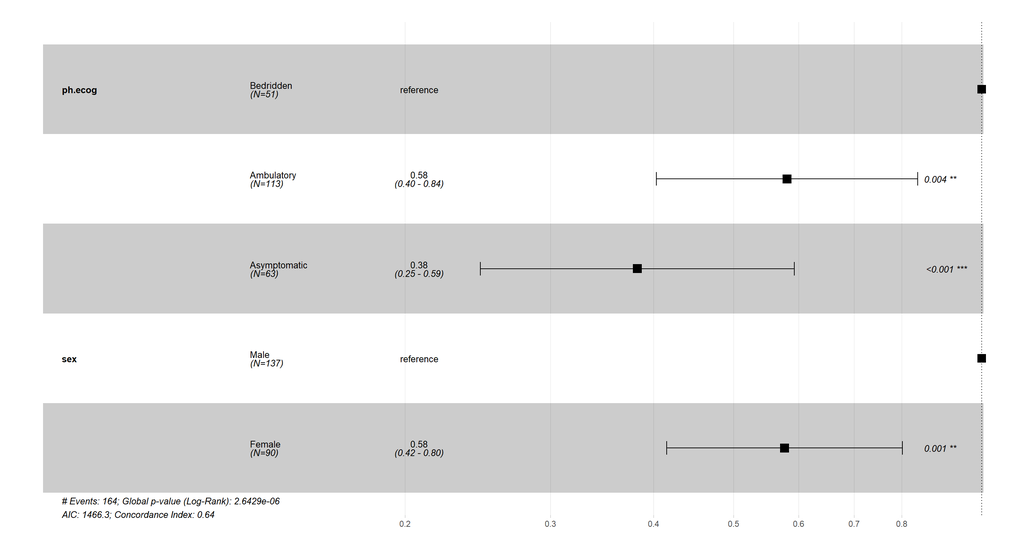

```r
(DBP.Analysis.MultivariateCoxPH.DBP.Analysis.MultivariateCoxPH.PhEcogSex.ForestPlot <- ggforest(DBP.Analysis.MultivariateCoxPH.PhEcogSex,
          data=DBP.Analysis.Filtered,
          main = "",
          fontsize = 0.9))
```

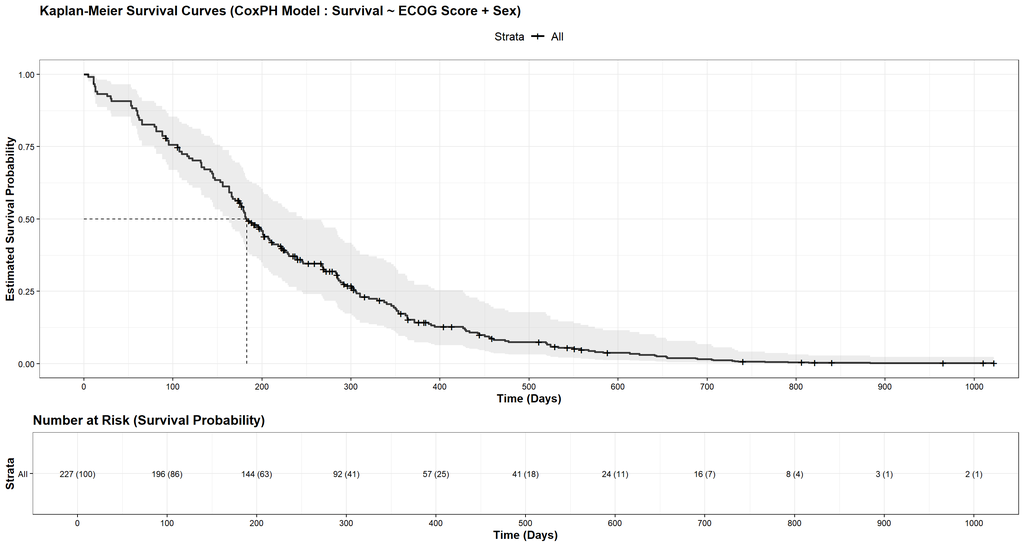

```r
##################################
# Plotting the Kaplan-Meier survival curves
# for the formulated Multivariate Cox Proportional Hazards Model
# involving the Factor and Covariate variables
##################################
DBP.Analysis.MultivariateCoxPH.PhEcogSex.KaplanMeierEstimates <- survfit(DBP.Analysis.MultivariateCoxPH.PhEcogSex , data = DBP.Analysis.Filtered)

SurvivalTimeInWeek.KaplanMeier.MultivariateCoxPH.PhEcogSex <- ggsurvplot(DBP.Analysis.MultivariateCoxPH.PhEcogSex.KaplanMeierEstimates,
                                                     title = "Kaplan-Meier Survival Curves (CoxPH Model : Survival ~ ECOG Score + Sex)",
                                                     pval = FALSE,
                                                     conf.int = TRUE,
                                                     conf.int.style = "ribbon",
                                                     xlab = "Time (Days)",
                                                     ylab="Estimated Survival Probability",
                                                     break.time.by = 100,
                                                     ggtheme = theme_bw(),
                                                     risk.table = "abs_pct",
                                                     risk.table.title="Number at Risk (Survival Probability)",
                                                     risk.table.y.text.col = FALSE,
                                                     risk.table.y.text = TRUE,
                                                     fontsize = 3,
                                                     ncensor.plot = FALSE,
                                                     surv.median.line = "hv",
                                                     palette = c("#000000"))

ggpar(SurvivalTimeInWeek.KaplanMeier.MultivariateCoxPH.PhEcogSex,
      font.title = c(14,"bold"),
      font.x = c(12,"bold"),
      font.y = c(12,"bold"),
      font.legend=c(12),
      font.xtickslab=c(9,"black"),
      font.ytickslab=c(9,"black"))
```

```r
##################################
# Plotting the Kaplan-Meier survival curves
# of the Factor variable adjusted by the Covariate variable
# using the formulated Multivariate Cox Proportional Hazards Model
##################################

(DBP.PhEcogAdjustedBySex <- with(DBP.Analysis.Filtered,
                                 data.frame(ph.ecog = c("Bedridden", "Ambulatory","Asymptomatic"),
                                            sex = c("Male", "Male", "Male"))))
```

```
##        ph.ecog  sex
## 1    Bedridden Male
## 2   Ambulatory Male
## 3 Asymptomatic Male
```